# **AIML Module Project - Applied Statistics** - Total Score 60

# Part A - 15 Marks

## Please answer the following questions with all relevant assumptions, explanations and details

### Import the libraries

```python
# import the important packages
import pandas as pd  # library used for data manipulation and analysis
import numpy as np  # library used for working with arrays
import matplotlib.pyplot as plt  # library for plots and visualizations
import seaborn as sns  # library for visualizations
import math

%matplotlib inline

import scipy.stats as stats  # this library contains a large number of probability distributions as well as a growing library of statistical functions
```

### 1. Please refer the table below to answer below questions: [2 Marks]

| Planned to purchase Product A | Actually placed order for Product A - Yes | Actually placed order for Product A - No | Total |
| --- | --- | --- | --- |
| Yes | 400 | 100 | 500 |
| No | 200 | 1300 | 1500 |
| Total | 600 | 1400 | 2000 |

Let

P = Planned to Purchase

Q = Actually placed an order

n(P) = Number of cases in favour of P = 500

n(Q) = Number of cases in favour of Q = 600

N = Total Number of Purchase = 2000

L intersection Q = 400

$P(L \cap Q) = \frac{n(L \cap Q)} {Total \quad Number \quad of \quad observations}$

#### 1.A. Refer above table and find the joint probability of the people who planned to purchase and actually placed an order. [1 Mark]

```python
FE4 = 400
TE  = 2000
PE4 = round(FE4 / TE,4)
print('a.Probability that  people who planned to purchase and actually placed an order is %1.2f' % PE4)
```

```
a.Probability that  people who planned to purchase and actually placed an order is 0.20
```

#### 1.B. Refer to the above table and find the joint probability of the people who planned to purchase and actually placed an order, given that people planned to purchase. [1 Mark]

```python
# given people planned to purchase
#P(Planned to purchase and acutally placed an order)
FE1 = 400
#P(Planned to purchase)
TE1  = 500
PE1 = round(FE1 / TE1,4)
print('b.Probability that  people who planned to purchase and actually placed an order, given that people planned to purchase is %1.2f' % PE1)
```

```
b.Probability that  people who planned to purchase and actually placed an order, given that people planned to purchase is 0.80
```

### 2. An electrical manufacturing company conducts quality checks at specified periods on the products it manufactures. Historically, the failure rate for the manufactured item is 5%. Suppose a random sample of 10 manufactured items is selected. Answer the following questions. [4 Marks]

```python
# import the required function
from scipy.stats import binom
# declare the sample size in variable n which represents the number of items selected randomly
n = 10
# declare p which represents the probability of sample is defective
p = 0.05
```

#### 2.A. Probability that none of the items are defective? [1 Mark]

```python
twoa = binom.pmf(k=0, n=10, p=0.05)
print('b.Probability that none of the items are defective is %1.3f' % twoa)
```

```
b.Probability that none of the items are defective is 0.599
```

#### 2.B. Probability that exactly one of the items is defective? [1 Mark]

```python
twob =binom.pmf(k=1, n=10, p=0.05)
print('b.Probability that exactly one of the items is defective is %1.3f' % twob)
```

```
b.Probability that exactly one of the items is defective is 0.315
```

#### 2.C. Probability that two or fewer of the items are defective? [1 Mark]

```python
twoc = binom.cdf(k=2, n=10, p=0.05)
print('b.Probability that two or fewer of the items are defective is %1.3f' % twoc)
```

```
b.Probability that two or fewer of the items are defective is 0.988
```

#### 2.D. Probability that three or more of the items are defective ? [1 Mark]

```python
twod = 1-binom.cdf(k=2, n=10, p=0.05)
print('b.Probability that three or more of the items are defective is %1.3f' % twod)
```

```
b.Probability that three or more of the items are defective is 0.012
```

### 3. A car salesman sells on an average 3 cars per week. [3 Marks]

```python
lamb = 3
n = np.arange(0,20)

poisson = stats.poisson.pmf(n,lamb)
poisson
```

```
array([4.97870684e-02, 1.49361205e-01, 2.24041808e-01, 2.24041808e-01,
       1.68031356e-01, 1.00818813e-01, 5.04094067e-02, 2.16040315e-02,
       8.10151179e-03, 2.70050393e-03, 8.10151179e-04, 2.20950322e-04,
       5.52375804e-05, 1.27471339e-05, 2.73152870e-06, 5.46305740e-07,
       1.02432326e-07, 1.80762929e-08, 3.01271548e-09, 4.75691918e-10])
```

#### 3.A. What is Probability that in a given week he will sell some cars? [1 Mark]

```python
# P = probability that he will sell at least one car
P   = 1 - poisson[0]
print(' a) probability that he will sell at least one car is %0.3f' % P)
```

```
 a) probability that he will sell at least one car is 0.950
```

#### 3.B. What is Probability that in a given week he will sell 2 or more but less than 5 cars? [1 Mark]

```python
# P = probability that he will sell 2 or more but less than 5 cars
P   = poisson[2]+poisson[3]+poisson[4]
print(' b) probability that he will sell 2 or more but less than 5 cars is %1.3f' % P)
```

```
 b) probability that he will sell 2 or more but less than 5 cars is 0.616
```

#### 3.C. Plot the poisson distribution function for cumulative probability of cars sold per-week vs number of cars sold per week. [1 Mark]

[figure not shown]

```python
fig=plt.figure();
plt.figure(figsize=(8,6))
prob_dist_cum = stats.poisson.cdf(n,lamb)
plt.plot(n,prob_dist_cum, 'o-')
plt.title('Cumulative Probability Distribution')
plt.xlabel('Cumulative Probability')
plt.ylabel('Cars sold per-week')
plt.show()
```

### 4. Accuracy in understanding orders for a speech based bot at a restaurant is important for the Company X which has designed, marketed and launched the product for a contactless delivery due to the COVID-19 pandemic. Recognition accuracy that measures the percentage of orders that are taken correctly is 86.8%. Suppose that you place an order with the bot and two friends of yours independently place orders with the same bot. Answer the following questions. [3 Marks]

```python
p   =  0.868 # percentage of orders filled correctly at Wendy's was approximately 86.8%
n   =  3
k   =  np.arange(0,4)

from scipy import stats
binomial = stats.binom.pmf(k,n,p)

print(binomial)
```

```
[0.00229997 0.0453721  0.2983559  0.65397203]
```

#### 4.A. What is the probability that all three orders will be recognised correctly? [1 Mark]

```python
print('a) all the three orders are recognised correctly? is %1.3f' %binomial[3])
```

```
a) all the three orders are recognised correctly? is 0.654
```

#### 4.B. What is the probability that none of the three orders will be recognised correctly? [1 Mark]

```python
print('b) none of the three orders are recognised correctly? is %1.3f' %binomial[0])
```

```
b) none of the three orders are recognised correctly? is 0.002
```

#### 4.C. What is the probability that at least two of the three orders will be recognised correctly? [1 Mark]

```python
P = binomial[2] + binomial[3]
print('c) atleast two of the three orders are recognised correctly? is %1.3f' % P)
```

```
c) atleast two of the three orders are recognised correctly? is 0.952
```

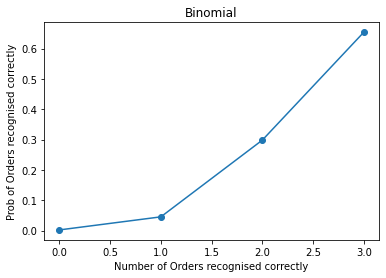

```python
import matplotlib.pyplot as plt
plt.plot(k,binomial, 'o-')
plt.title('Binomial')
plt.xlabel('Number of Orders recognised correctly')
plt.ylabel('Prob of Orders recognised correctly')
plt.show()
```

### 5. Explain 1 real life industry scenario (other than the ones mentioned above) where you can use the concepts learnt in this module of Applied Statistics to get data driven business solution. [3 Marks]

In statistics and probability theory, the Bayes’ theorem (also known as the Bayes’ rule) is a mathematical formula used to determine the conditional probability of events. Essentially, the Bayes’ theorem describes the probability of an event based on prior knowledge of the conditions that might be relevant to the event.

$P(A|B) = \frac{P(B|A)P(A)} {P(B)}$

Where:

P(A|B) – the probability of event A occurring, given event B has occurred

P(B|A) – the probability of event B occurring, given event A has occurred

P(A) – the probability of event A

P(B) – the probability of event B

Imagine you are a financial analyst at an investment bank. According to your research of publicly-traded companies, 60% of the companies that increased their share price by more than 5% in the last three years replaced their CEOs during the period.

At the same time, only 35% of the companies that did not increase their share price by more than 5% in the same period replaced their CEOs. Knowing that the probability that the stock prices grow by more than 5% is 4%, find the probability that the shares of a company that fires its CEO will increase by more than 5%.

Before finding the probabilities, you must first define the notation of the probabilities.

P(A) – the probability that the stock price increases by 5%

P(B) – the probability that the CEO is replaced

P(A|B) – the probability of the stock price increases by 5% given that the CEO has been replaced

P(B|A) – the probability of the CEO replacement given the stock price has increased by 5%.

Using the Bayes’ theorem, we can find the required probability:

$P(A|B) = \frac{P(B|A)P(A)} {P(B|A-)P(A-) + P(B|A+)P(A+)}$

$P(A|B) = \frac{0.60X0.04} {0.60X0.04 + 0.35X(1-0.04)}$

Thus, the probability that the shares of a company that replaces its CEO will grow by more than 5% is 6.67%.

Some other Real life scenarios includes:

Government – The government use statistical data to tale decisions regarding populations, health and education and subsequent budgeting on the same. It may research on data collected from several schools to check out if all the protocols are being followed or not.

Science and Medicine – Research work of the effects of medicines are carried out from samples taken randomly. It helps to know which medicines are working well, from random samples. Taking whole population figures is not always possible. Doctors make forecasts based on statistical concepts. When you take a random population, you study the causes and effects of ceratin diseases.

Psychology Field – Data on human behaviour is collected from the population, through statistical measure like random sampling and localized sampling techniques. We will further elaborate on that, as we go along.

Education – Teachers are also using the same evaluation methods in the classroom. They try to figure out, which method of pedagogy works and which does not. They also require to find out, regarding the performance of the students in the classroom.

# Part B - 30 Marks

**• DOMAIN:** Sports

**• CONTEXT:** Company X manages the men's top professional basketball division of the American league system. The dataset contains information on all the teams that have participated in all the past tournaments. It has data about how many baskets each team scored, conceded, how many times they came within the first 2 positions, how many tournaments they have qualified, their best position in the past, etc.

**• DATA DESCRIPTION:** Basketball.csv - The data set contains information on all the teams so far participated in all the past tournaments.

**• DATA DICTIONARY:**

1. Team: Team’s name
2. Tournament: Number of played tournaments.
3. Score: Team’s score so far.
4. PlayedGames: Games played by the team so far.
5. WonGames: Games won by the team so far.
6. DrawnGames: Games drawn by the team so far.
7. LostGames: Games lost by the team so far.
8. BasketScored: Basket scored by the team so far.
9. BasketGiven: Basket scored against the team so far.
10. TournamentChampion: How many times the team was a champion of the tournaments so far.
11. Runner-up: How many times the team was a runners-up of the tournaments so far.
12. TeamLaunch: Year the team was launched on professional basketball.
13. HighestPositionHeld: Highest position held by the team amongst all the tournaments played.

**• PROJECT OBJECTIVE:** Company’s management wants to invest on proposals on managing some of the best teams in the league. The analytics department has been assigned with a task of creating a report on the performance shown by the teams. Some of the older teams are already in contract with competitors. Hence Company X wants to understand which teams they can approach which will be a deal win for them.

#### STEPS AND TASK [30 Marks]:

### 1. Read the data set, clean the data and prepare final dataset to be used for analysis. [10 Marks]

```python
#importing necessary libraries
import pandas as pd
import numpy as np
from datetime import datetime, date
import statsmodels.api as sm
from statsmodels.formula.api import ols
from statsmodels.stats.anova import anova_lm

import matplotlib.pyplot as plt
import seaborn as sns
%matplotlib inline
```

```python
# Read data and check for first 5 rows
basketball_data_raw = pd.read_csv('Basketball.csv')
basketball_data_raw.head(5)
```

|  | Team | Tournament | Score | PlayedGames | WonGames | DrawnGames | LostGames | BasketScored | BasketGiven | TournamentChampion | Runner-up | TeamLaunch | HighestPositionHeld |
| --- | --- | --- | --- | --- | --- | --- | --- | --- | --- | --- | --- | --- | --- |
| 0 | Team 1 | 86 | 4385 | 2762 | 1647 | 552 | 563 | 5947 | 3140 | 33 | 23 | 1929 | 1 |
| 1 | Team 2 | 86 | 4262 | 2762 | 1581 | 573 | 608 | 5900 | 3114 | 25 | 25 | 1929 | 1 |
| 2 | Team 3 | 80 | 3442 | 2614 | 1241 | 598 | 775 | 4534 | 3309 | 10 | 8 | 1929 | 1 |
| 3 | Team 4 | 82 | 3386 | 2664 | 1187 | 616 | 861 | 4398 | 3469 | 6 | 6 | 1931to32 | 1 |
| 4 | Team 5 | 86 | 3368 | 2762 | 1209 | 633 | 920 | 4631 | 3700 | 8 | 7 | 1929 | 1 |

#### a. Shape of the data

```python
basketball_data_raw.shape #61 rows and 13 columns
```

```
(61, 13)
```

```python
basketball_data_raw.info()
```

```
<class 'pandas.core.frame.DataFrame'>
RangeIndex: 61 entries, 0 to 60
Data columns (total 13 columns):
 #   Column               Non-Null Count  Dtype
---  ------               --------------  -----
 0   Team                 61 non-null     object
 1   Tournament           61 non-null     int64
 2   Score                61 non-null     object
 3   PlayedGames          61 non-null     object
 4   WonGames             61 non-null     object
 5   DrawnGames           61 non-null     object
 6   LostGames            61 non-null     object
 7   BasketScored         61 non-null     object
 8   BasketGiven          61 non-null     object
 9   TournamentChampion   61 non-null     object
 10  Runner-up            61 non-null     object
 11  TeamLaunch           61 non-null     object
 12  HighestPositionHeld  61 non-null     int64
dtypes: int64(2), object(11)
memory usage: 6.3+ KB
```

All columns have not-null entries

```python
# check datatypes
basketball_data_raw.dtypes
```

```
Team                   object
Tournament              int64
Score                  object
PlayedGames            object
WonGames               object
DrawnGames             object
LostGames              object
BasketScored           object
BasketGiven            object
TournamentChampion     object
Runner-up              object
TeamLaunch             object
HighestPositionHeld     int64
dtype: object
```

There are in total 61 rows and 13 attributes in the dataset. Out of which, only 2 attributes are numeric and remaining are object. We need to check if there are any odd entries in column.

```python
basketball_data_raw.describe(include='all').T
```

|  | count | unique | top | freq | mean | std | min | 25% | 50% | 75% | max |
| --- | --- | --- | --- | --- | --- | --- | --- | --- | --- | --- | --- |
| Team | 61 | 61 | Team 1 | 1 | NaN | NaN | NaN | NaN | NaN | NaN | NaN |
| Tournament | 61.0 | NaN | NaN | NaN | 24.0 | 26.827225 | 1.0 | 4.0 | 12.0 | 38.0 | 86.0 |
| Score | 61 | 61 | 4385 | 1 | NaN | NaN | NaN | NaN | NaN | NaN | NaN |
| PlayedGames | 61 | 53 | 2762 | 3 | NaN | NaN | NaN | NaN | NaN | NaN | NaN |
| WonGames | 61 | 59 | 7 | 2 | NaN | NaN | NaN | NaN | NaN | NaN | NaN |
| DrawnGames | 61 | 57 | 14 | 2 | NaN | NaN | NaN | NaN | NaN | NaN | NaN |
| LostGames | 61 | 56 | 37 | 3 | NaN | NaN | NaN | NaN | NaN | NaN | NaN |
| BasketScored | 61 | 60 | 70 | 2 | NaN | NaN | NaN | NaN | NaN | NaN | NaN |
| BasketGiven | 61 | 61 | 3140 | 1 | NaN | NaN | NaN | NaN | NaN | NaN | NaN |
| TournamentChampion | 61 | 8 | - | 52 | NaN | NaN | NaN | NaN | NaN | NaN | NaN |
| Runner-up | 61 | 10 | - | 48 | NaN | NaN | NaN | NaN | NaN | NaN | NaN |
| TeamLaunch | 61 | 47 | 1929 | 10 | NaN | NaN | NaN | NaN | NaN | NaN | NaN |
| HighestPositionHeld | 61.0 | NaN | NaN | NaN | 7.081967 | 5.276663 | 1.0 | 3.0 | 6.0 | 10.0 | 20.0 |

```python
# Make a copy
basketball_data = basketball_data_raw.copy(deep=True)
```

```python
#Rename Runner-up to Runner_up
basketball_data = basketball_data.rename(columns={"Runner-up": "Runner_up"})
```

The columns(Score,PlayedGames,WonGames,DrawnGames,LostGames,BasketScored,BasketGiven,TournamentChampion,Runner-up) have "-" instead of "0". So we need to replace "-" with values "0" for our analysis

```python
basketball_data.replace('-',np.nan,inplace=True)
basketball_data = basketball_data.fillna(0)
```

```python
basketball_data.info()
```

```
<class 'pandas.core.frame.DataFrame'>
RangeIndex: 61 entries, 0 to 60
Data columns (total 13 columns):
 #   Column               Non-Null Count  Dtype
---  ------               --------------  -----
 0   Team                 61 non-null     object
 1   Tournament           61 non-null     int64
 2   Score                61 non-null     object
 3   PlayedGames          61 non-null     object
 4   WonGames             61 non-null     object
 5   DrawnGames           61 non-null     object
 6   LostGames            61 non-null     object
 7   BasketScored         61 non-null     object
 8   BasketGiven          61 non-null     object
 9   TournamentChampion   61 non-null     object
 10  Runner_up            61 non-null     object
 11  TeamLaunch           61 non-null     object
 12  HighestPositionHeld  61 non-null     int64
dtypes: int64(2), object(11)
memory usage: 6.3+ KB
```

Numeric attributes: Tournament,Score,PlayedGames,WonGames,DrawnGames,LostGames,BasketScored,BasketGiven,TournamentChampion,Runner-up,HighestPositionHeld

Object attributes: Team, TeamLaunch

```python
basketball_data = basketball_data.astype({"Score":'int64', "PlayedGames":'int64', "WonGames":'int64',
                                          "DrawnGames":'int64',"LostGames":'int64', "BasketScored":'int64',
                                          "BasketGiven":'int64', "TournamentChampion":'int64', "Runner_up":'int64'})
```

```python
basketball_data.info()
```

```
<class 'pandas.core.frame.DataFrame'>
RangeIndex: 61 entries, 0 to 60
Data columns (total 13 columns):
 #   Column               Non-Null Count  Dtype
---  ------               --------------  -----
 0   Team                 61 non-null     object
 1   Tournament           61 non-null     int64
 2   Score                61 non-null     int64
 3   PlayedGames          61 non-null     int64
 4   WonGames             61 non-null     int64
 5   DrawnGames           61 non-null     int64
 6   LostGames            61 non-null     int64
 7   BasketScored         61 non-null     int64
 8   BasketGiven          61 non-null     int64
 9   TournamentChampion   61 non-null     int64
 10  Runner_up            61 non-null     int64
 11  TeamLaunch           61 non-null     object
 12  HighestPositionHeld  61 non-null     int64
dtypes: int64(11), object(2)
memory usage: 6.3+ KB
```

```python
basketball_data["YearLaunch"] = basketball_data["TeamLaunch"].apply(lambda x:x.split('to')[0])
```

```python
basketball_data.head()
```

|  | Team | Tournament | Score | PlayedGames | WonGames | DrawnGames | LostGames | BasketScored | BasketGiven | TournamentChampion | Runner_up | TeamLaunch | HighestPositionHeld | YearLaunch |
| --- | --- | --- | --- | --- | --- | --- | --- | --- | --- | --- | --- | --- | --- | --- |
| 0 | Team 1 | 86 | 4385 | 2762 | 1647 | 552 | 563 | 5947 | 3140 | 33 | 23 | 1929 | 1 | 1929 |
| 1 | Team 2 | 86 | 4262 | 2762 | 1581 | 573 | 608 | 5900 | 3114 | 25 | 25 | 1929 | 1 | 1929 |
| 2 | Team 3 | 80 | 3442 | 2614 | 1241 | 598 | 775 | 4534 | 3309 | 10 | 8 | 1929 | 1 | 1929 |
| 3 | Team 4 | 82 | 3386 | 2664 | 1187 | 616 | 861 | 4398 | 3469 | 6 | 6 | 1931to32 | 1 | 1931 |
| 4 | Team 5 | 86 | 3368 | 2762 | 1209 | 633 | 920 | 4631 | 3700 | 8 | 7 | 1929 | 1 | 1929 |

The Numeric columns are converted to integer datatype. Now the TeamLaunch attribute, this has multiple types of anomalous data as below:

The column(TeamLaunch) has various characters to split like "-,to,~,_". To make it uniform we will now remove these using lambda function and will retain only the first year (in combined year only) in a seperate column called "YearLaunch" and we create a new column called "Age" which contains the age of the team in years.

```python
def comb2single(x):
    if 'to' in x:
        return x.split('to')[0]
    elif '-' in x:
        return x.split('-')[0]
    if '~' in x:
        return x.split('~')[0]
    if '_' in x:
        return x.split('_')[0]
    else:
        return x

basketball_data["YearLaunch"] = basketball_data["TeamLaunch"].apply(comb2single)
#convert YearLaunch to int64
basketball_data = basketball_data.astype({"YearLaunch":np.int64})
today = date.today()
#subtract yearlaunch to current date to get team age
basketball_data["Age"] = basketball_data["YearLaunch"].apply(lambda x: today.year-x)
```

```python
basketball_data.head()
```

|  | Team | Tournament | Score | PlayedGames | WonGames | DrawnGames | LostGames | BasketScored | BasketGiven | TournamentChampion | Runner_up | TeamLaunch | HighestPositionHeld | YearLaunch | Age |
| --- | --- | --- | --- | --- | --- | --- | --- | --- | --- | --- | --- | --- | --- | --- | --- |
| 0 | Team 1 | 86 | 4385 | 2762 | 1647 | 552 | 563 | 5947 | 3140 | 33 | 23 | 1929 | 1 | 1929 | 93 |
| 1 | Team 2 | 86 | 4262 | 2762 | 1581 | 573 | 608 | 5900 | 3114 | 25 | 25 | 1929 | 1 | 1929 | 93 |
| 2 | Team 3 | 80 | 3442 | 2614 | 1241 | 598 | 775 | 4534 | 3309 | 10 | 8 | 1929 | 1 | 1929 | 93 |
| 3 | Team 4 | 82 | 3386 | 2664 | 1187 | 616 | 861 | 4398 | 3469 | 6 | 6 | 1931to32 | 1 | 1931 | 91 |
| 4 | Team 5 | 86 | 3368 | 2762 | 1209 | 633 | 920 | 4631 | 3700 | 8 | 7 | 1929 | 1 | 1929 | 93 |

```python
#Dropping TeamLaunch and proceeding
basketball_data.drop('TeamLaunch',axis=1,inplace=True)
```

For analysis introducing 5 new attributes

**Basket_Diff** - Difference between 'BasketScored' & 'BasketGiven' per 'PlayedGames'

**Win_Percent** - Percentage of 'WonGames' over 'PlayedGames'

**Podium_Fin** - Percentage of Podium Finishes ('TournamentsChampion'+'Runner_up') over 'Tournament'

**SPG** - 'Score' over PlayedGames

**Tour_Percent** - Percentage 'Tournament' over 'Age'

```python
basketball_data['Basket_Diff'] = (basketball_data['BasketScored'] - basketball_data['BasketGiven'])/basketball_data['PlayedGames'].fillna(value=0)
basketball_data['Win_Percent'] = basketball_data['WonGames']/basketball_data['PlayedGames'].fillna(value=0)*100
basketball_data['Podium_Fin'] = (basketball_data['TournamentChampion']+basketball_data['Runner_up'])/basketball_data['Tournament']*100
basketball_data['SPG'] = basketball_data['Score']/basketball_data['PlayedGames'].fillna(value=0)
basketball_data['Tour_Percent'] = (basketball_data['Tournament']/basketball_data['Age'])*100
```

```python
basketball_data.head()
```

|  | Team | Tournament | Score | PlayedGames | WonGames | DrawnGames | LostGames | BasketScored | BasketGiven | TournamentChampion | Runner_up | HighestPositionHeld | YearLaunch | Age | Basket_Diff | Win_Percent | Podium_Fin | SPG | Tour_Percent |
| --- | --- | --- | --- | --- | --- | --- | --- | --- | --- | --- | --- | --- | --- | --- | --- | --- | --- | --- | --- |
| 0 | Team 1 | 86 | 4385 | 2762 | 1647 | 552 | 563 | 5947 | 3140 | 33 | 23 | 1 | 1929 | 93 | 1.016293 | 59.630702 | 65.116279 | 1.587618 | 92.473118 |
| 1 | Team 2 | 86 | 4262 | 2762 | 1581 | 573 | 608 | 5900 | 3114 | 25 | 25 | 1 | 1929 | 93 | 1.008689 | 57.241130 | 58.139535 | 1.543085 | 92.473118 |
| 2 | Team 3 | 80 | 3442 | 2614 | 1241 | 598 | 775 | 4534 | 3309 | 10 | 8 | 1 | 1929 | 93 | 0.468630 | 47.475134 | 22.500000 | 1.316756 | 86.021505 |
| 3 | Team 4 | 82 | 3386 | 2664 | 1187 | 616 | 861 | 4398 | 3469 | 6 | 6 | 1 | 1931 | 91 | 0.348724 | 44.557057 | 14.634146 | 1.271021 | 90.109890 |
| 4 | Team 5 | 86 | 3368 | 2762 | 1209 | 633 | 920 | 4631 | 3700 | 8 | 7 | 1 | 1929 | 93 | 0.337075 | 43.772629 | 17.441860 | 1.219406 | 92.473118 |

### 2. Perform detailed statistical analysis and EDA using univariate, bi-variate and multivariate EDA techniques to get data driven insights on recommending which teams they can approach which will be a deal win for them. Also as a data and statistics expert you have to develop a detailed performance report using this data. [10 Marks]

Hint: Use statistical techniques and visualisation techniques to come up with useful metrics and reporting. Find out the best performing team, oldest team, team with highest goals, team with lowest performance etc. and many more. These are just random examples. Please use your best analytical approach to build this report. You can mix match columns to create new ones which can be used for better analysis. Create your own features if required. Be highly experimental and analytical here to find hidden patterns. Use graphical interactive libraries to enable you to publish interactive plots in python.

```python
#Dropping unnecessary columns
basketball_data.drop(['WonGames','DrawnGames','LostGames','BasketScored','BasketGiven','TournamentChampion','Runner_up'],inplace=True,axis=1)
```

```python
basketball_data.describe()
```

|  | Tournament | Score | PlayedGames | HighestPositionHeld | YearLaunch | Age | Basket_Diff | Win_Percent | Podium_Fin | SPG | Tour_Percent |
| --- | --- | --- | --- | --- | --- | --- | --- | --- | --- | --- | --- |
| count | 61.000000 | 61.000000 | 61.000000 | 61.000000 | 61.000000 | 61.000000 | 60.000000 | 60.000000 | 61.000000 | 60.000000 | 61.000000 |
| mean | 24.000000 | 901.426230 | 796.819672 | 7.081967 | 1958.918033 | 63.081967 | -0.369488 | 31.364790 | 3.645135 | 0.978535 | 33.795898 |
| std | 26.827225 | 1134.899121 | 876.282765 | 5.276663 | 27.484114 | 27.484114 | 0.435745 | 7.831199 | 11.670006 | 0.215741 | 28.412371 |
| min | 1.000000 | 0.000000 | 0.000000 | 1.000000 | 1929.000000 | 5.000000 | -1.647059 | 16.666667 | 0.000000 | 0.466667 | 1.408451 |
| 25% | 4.000000 | 96.000000 | 114.000000 | 3.000000 | 1935.000000 | 44.000000 | -0.579302 | 27.607494 | 0.000000 | 0.827361 | 10.169492 |
| 50% | 12.000000 | 375.000000 | 423.000000 | 6.000000 | 1951.000000 | 71.000000 | -0.415868 | 30.491722 | 0.000000 | 0.988248 | 22.988506 |
| 75% | 38.000000 | 1351.000000 | 1318.000000 | 10.000000 | 1978.000000 | 87.000000 | -0.247259 | 33.540164 | 0.000000 | 1.069980 | 55.128205 |
| max | 86.000000 | 4385.000000 | 2762.000000 | 20.000000 | 2017.000000 | 93.000000 | 1.016293 | 59.630702 | 65.116279 | 1.587618 | 92.473118 |

[output not shown]

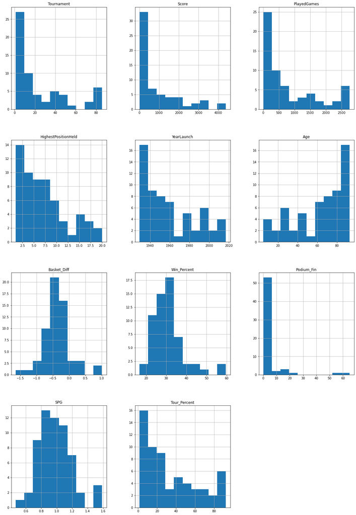

```python
import matplotlib.pyplot as plt
%matplotlib inline

basketball_data.hist(figsize=(20,30))
```

Coming to the problem:

```
1.The company wants to know a list of portable candidates team where they can invest for good returns. We will target 4-5 teams as a recommendation.
2.We know that some of the older teams have sponsorship with competitors, but we do not know which older teams. Hence, we will analyze both older teams except the oldest and recently launched teams.
```

### Measure of CT (3Ms) and Distributions

Measure of central tendency describes the entire dataset with a single value or metric which represents the middle or center of distribution. It is also known as measure of center or central location.

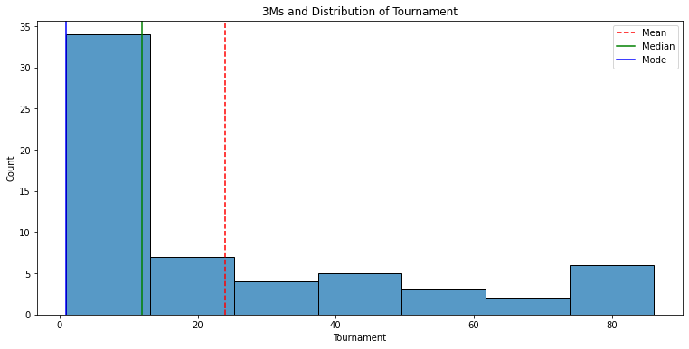

```python
# Distribution of 'Tournament' alongwith measure of CT (3Ms)
Tournament_mean = basketball_data['Tournament'].mean()
Tournament_median = basketball_data['Tournament'].median()
Tournament_mode = basketball_data['Tournament'].mode()

fig, ax_hist = plt.subplots(figsize = (12.8, 6))
ax_hist = sns.histplot(basketball_data['Tournament'])

ax_hist.axvline(Tournament_mean, color = 'r', linestyle = '--', label = 'Mean')
ax_hist.axvline(Tournament_median, color = 'g', linestyle = '-', label = 'Median')
ax_hist.axvline(Tournament_mode[0], color = 'b', linestyle = '-', label = 'Mode')
ax_hist.set_title('3Ms and Distribution of Tournament')

plt.legend(); plt.show()
```

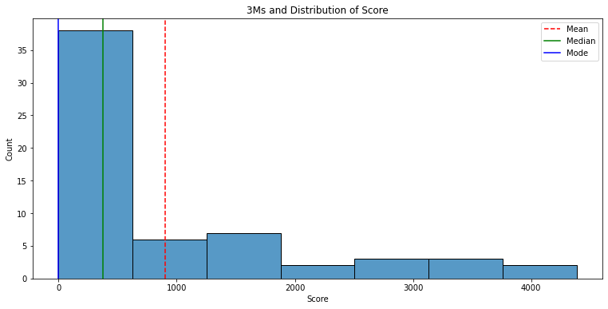

```python
# Distribution of 'Score' alongwith measure of CT (3Ms)
Score_mean = basketball_data['Score'].mean()
Score_median = basketball_data['Score'].median()
Score_mode = basketball_data['Score'].mode()

fig, ax_hist = plt.subplots(figsize = (12.8, 6))
ax_hist = sns.histplot(basketball_data['Score'])

ax_hist.axvline(Score_mean, color = 'r', linestyle = '--', label = 'Mean')
ax_hist.axvline(Score_median, color = 'g', linestyle = '-', label = 'Median')
ax_hist.axvline(Score_mode[0], color = 'b', linestyle = '-', label = 'Mode')
ax_hist.set_title('3Ms and Distribution of Score')

plt.legend(); plt.show()
```

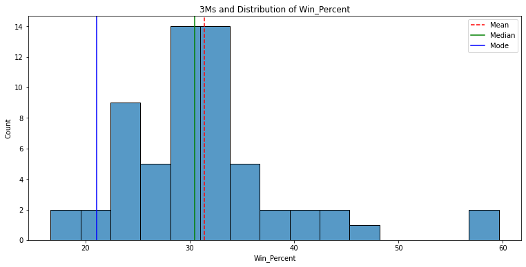

```python
# Distribution of 'Win_Percent' alongwith measure of CT (3Ms)
Win_Percent_mean = basketball_data['Win_Percent'].mean()
Win_Percent_median = basketball_data['Win_Percent'].median()
Win_Percent_mode = basketball_data['Win_Percent'].mode()

fig, ax_hist = plt.subplots(figsize = (12.8, 6))
ax_hist = sns.histplot(basketball_data['Win_Percent'])

ax_hist.axvline(Win_Percent_mean, color = 'r', linestyle = '--', label = 'Mean')
ax_hist.axvline(Win_Percent_median, color = 'g', linestyle = '-', label = 'Median')
ax_hist.axvline(Win_Percent_mode[0], color = 'b', linestyle = '-', label = 'Mode')
ax_hist.set_title('3Ms and Distribution of Win_Percent')

plt.legend(); plt.show()
```

### Measure of skewness

Skewness is a measure of extent to which a distribution differs from a normal distribution.

The rule of thumb I would use here:

- If the skewness is between -0.5 and 0.5, the data are **fairly symmetrical**
- If the skewness is between -1 and -0.5(negatively skewed) or between 0.5 and 1(positively skewed), the data are **moderately skewed**
- If the skewness is less than -1(negatively skewed) or greater than 1(positively skewed), the data are **highly skewed**

```python
# Measure of Skewness and kurtosis for `Score`,`Win_Percent` columns
print("Skewness of 'Score': {}\n".format(basketball_data['Score'].skew().round(3)))

print("Skewness of 'Win_Percent': {}\n".format(basketball_data['Win_Percent'].skew().round(3)))
```

```
Skewness of 'Score': 1.593

Skewness of 'Win_Percent': 1.44
```

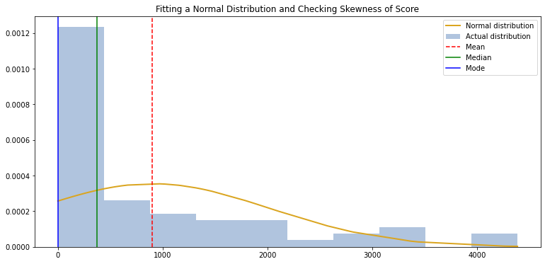

```python
# Fitting a normal distribution and ploting the result
h = np.asarray(basketball_data['Score'])
h = sorted(h)

#use the scipy stats module to fit a normal distirbution with same mean and standard deviation
fit = stats.norm.pdf(h, np.mean(h), np.std(h))

#plot both series on the histogram
fig, ax_hist = plt.subplots(figsize = (12.8, 6))
plt.plot(h, fit, '-', linewidth = 2, color = 'goldenrod', label = 'Normal distribution')
plt.hist(h, density = True, color = 'lightsteelblue', label = 'Actual distribution')

ax_hist.axvline(Score_mean, color = 'r', linestyle = '--', label = 'Mean')
ax_hist.axvline(Score_median, color = 'g', linestyle = '-', label = 'Median')
ax_hist.axvline(Score_mode[0], color = 'b', linestyle = '-', label = 'Mode')
ax_hist.set_title('Fitting a Normal Distribution and Checking Skewness of Score')

plt.legend(); plt.show()
```

We can see in the above graph that **`Score`** is **positively (right, Mode < Median < Mean) skewed** with **skewness score 1.593 (highly skewed)**.

[figure not shown]

```python
# Fitting a normal distribution and ploting the result
h = np.asarray(basketball_data['Win_Percent'])
h = sorted(h)

#use the scipy stats module to fit a normal distirbution with same mean and standard deviation
fit = stats.norm.pdf(h, np.mean(h), np.std(h))

#plot both series on the histogram
fig, ax_hist = plt.subplots(figsize = (12.8, 6))
plt.plot(h, fit, '-', linewidth = 2, color = 'goldenrod', label = 'Normal distribution')
plt.hist(h, density = True, color = 'lightsteelblue', label = 'Actual distribution')

ax_hist.axvline(Win_Percent_mean, color = 'r', linestyle = '--', label = 'Mean')
ax_hist.axvline(Win_Percent_median, color = 'g', linestyle = '-', label = 'Median')
ax_hist.axvline(Win_Percent_mode[0], color = 'b', linestyle = '-', label = 'Mode')
ax_hist.set_title('Fitting a Normal Distribution and Checking Skewness of Win_Percent')

plt.legend(); plt.show()
```

We can see in the above graph that **`Win_Percent`** is **positively (right, Mode < Median < Mean) skewed** with **skewness score 1.44 (highly skewed)**.

### Outliers imputation

In statistics, an outlier is an observation point that is distant from other observations.

**Ways to detect outliers**

- *Box Plot*: In descriptive statistics, a box plot is a method for graphically depicting groups of numerical data through their quartiles. Box plots may also have lines extending vertically from the boxes (whiskers) indicating variability outside the upper and lower quartiles, hence the terms box-and-whisker plot and box-and-whisker diagram. Outliers may be plotted as individual points.
- *Scatter Plot*: A scatter plot , is a type of plot or mathematical diagram using Cartesian coordinates to display values for typically two variables for a set of data. The data are displayed as a collection of points, each having the value of one variable determining the position on the horizontal axis and the value of the other variable determining the position on the vertical axis.
- *Z-score*: The Z-score is the signed number of standard deviations by which the value of an observation or data point is above the mean value of what is being observed or measured. In most of the cases a threshold of 3 or -3 is used i.e if the Z-score value is greater than or less than 3 or -3 respectively, that data point will be identified as outliers.
- *IQR score*: The interquartile range (IQR), also called the midspread or middle 50%, or technically H-spread, is a measure of statistical dispersion, being equal to the difference between 75th and 25th percentiles, or between upper and lower quartiles, IQR = Q3 − Q1. In other words, the IQR is the first quartile subtracted from the third quartile; these quartiles can be clearly seen on a box plot on the data. It is a measure of the dispersion similar to standard deviation or variance, but is much more robust against outliers.

I would be using Boxplot (to visualize), IQR (to display the columns) for outliers

|  | Team | Tournament | Score | PlayedGames | HighestPositionHeld | YearLaunch | Age | Basket_Diff | Win_Percent | Podium_Fin | SPG | Tour_Percent |
| --- | --- | --- | --- | --- | --- | --- | --- | --- | --- | --- | --- | --- |
| 0 | Team 1 | 86 | 4385 | 2762 | 1 | 1929 | 93 | 1.016293 | 59.630702 | 65.116279 | 1.587618 | 92.473118 |
| 1 | Team 2 | 86 | 4262 | 2762 | 1 | 1929 | 93 | 1.008689 | 57.241130 | 58.139535 | 1.543085 | 92.473118 |
| 2 | Team 3 | 80 | 3442 | 2614 | 1 | 1929 | 93 | 0.468630 | 47.475134 | 22.500000 | 1.316756 | 86.021505 |
| 3 | Team 4 | 82 | 3386 | 2664 | 1 | 1931 | 91 | 0.348724 | 44.557057 | 14.634146 | 1.271021 | 90.109890 |
| 4 | Team 5 | 86 | 3368 | 2762 | 1 | 1929 | 93 | 0.337075 | 43.772629 | 17.441860 | 1.219406 | 92.473118 |

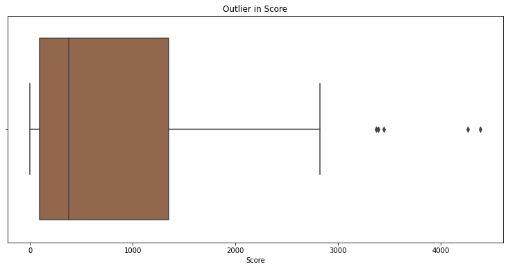

```python
# Outliers in Score
Q3 = basketball_data['Score'].quantile(0.75)
Q1 = basketball_data['Score'].quantile(0.25)
IQR = Q3 - Q1
display(basketball_data.loc[(basketball_data['Score'] < (Q1 - 1.5 * IQR)) | (basketball_data['Score'] > (Q3 + 1.5 * IQR))])

plt.figure(figsize = (12.8 , 6))
sns.boxplot(basketball_data['Score'], palette = 'copper').set_title('Outlier in Score')
```

`Score` column has many outliers

```
No artists with labels found to put in legend.  Note that artists whose label start with an underscore are ignored when legend() is called with no argument.
```

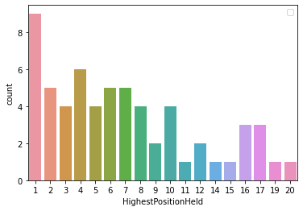

```python
#Plotting distribution of HighestPositionHeld
sns.countplot(x='HighestPositionHeld', data=basketball_data)
plt.legend()
```

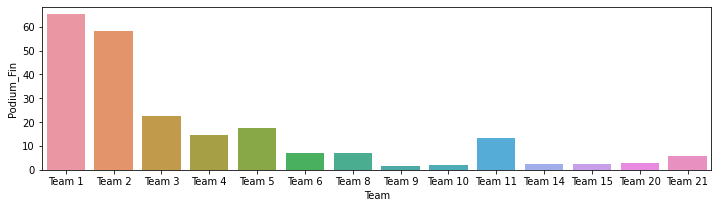

```python
#Plot of team against Podium_Fin
plt.figure(figsize=(12,3))
df_temp = basketball_data[basketball_data['Podium_Fin']>0]
sns.barplot(x=df_temp['Team'],y=df_temp['Podium_Fin'])
```

Only 14 teams have ever finished as Champion or Runner-up. Teams 1 and 2 are most successful with Podium Finishes in > 50% of the Tournaments.

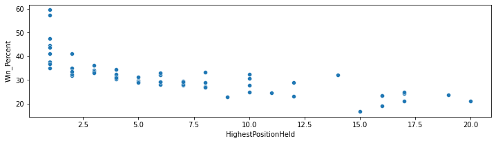

```python
#Plot of HighestPositionHeld against Win_Percent
plt.figure(figsize = (12,3))
df_temp = basketball_data[basketball_data['Win_Percent']>0]
sns.scatterplot(x=df_temp['HighestPositionHeld'],y=df_temp['Win_Percent']);
```

Teams with HighestPositionHeld <10 tend to have WinPercent > 20%

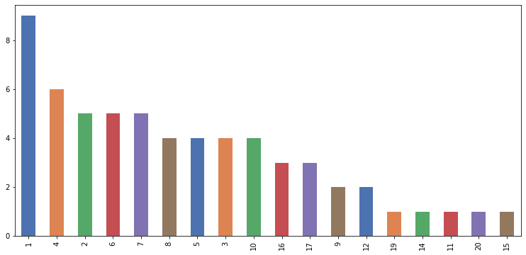

```python
# Distribution of HighestPositionHeld
plt.figure(figsize = (12.8 , 6))

basketball_data['HighestPositionHeld'].value_counts().plot.bar(color = sns.color_palette('deep', 6))
```

## Plotting univariate distributions

The most convenient way to take a quick look at a univariate distribution in seaborn is the distplot() function. By default, this will draw a histogram and fit a kernel density estimate (KDE).

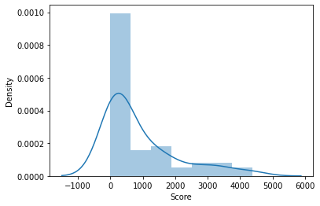

```python
sns.distplot(basketball_data['Score']);
```

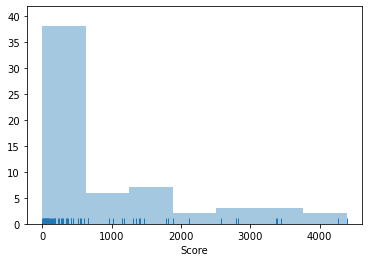

```python
# we can turn the kde off and put a tic mark along the x-axis for every data point with rug
sns.distplot(basketball_data['Score'], kde=False, rug=True);
```

## Plotting bivariate distributions

It can also be useful to visualize a relationship between two variables. The easiest way to do this in seaborn is to use the jointplot() function, which creates a scatterplot of the two variables along with the histograms of each next to the appropriate axes.

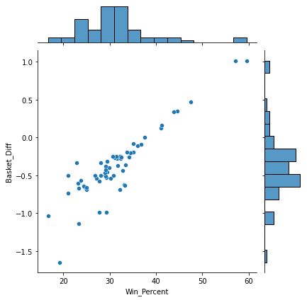

```python
sns.jointplot(basketball_data['Win_Percent'], basketball_data['Basket_Diff']);
```

### Hex Bin Plots

We can make a hex bin plot that breaks the 2D area into hexagons and the number of points in each hexagon determines the color

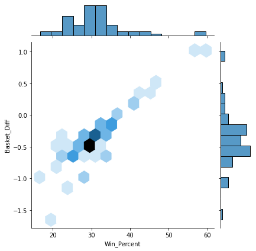

```python
sns.jointplot(basketball_data['Win_Percent'], basketball_data['Basket_Diff'], kind="hex");
```

### Kernel Density Estimation

We can make a 2D estimation of the density also

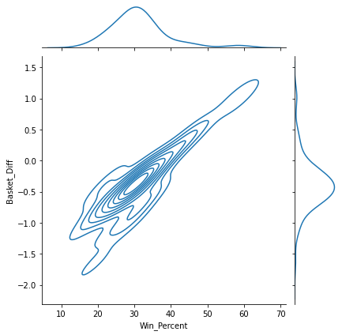

```python
sns.jointplot(basketball_data['Win_Percent'], basketball_data['Basket_Diff'], kind="kde");
```

## Visualizing pairwise relationships in a dataset

To plot multiple pairwise scatterplots in a dataset, you can use the pairplot() function. This creates a matrix of axes and shows the relationship for each pair of columns in a DataFrame, it also draws the histogram of each variable on the diagonal Axes:

Be careful about toggle scrolling in the cell menu!!!

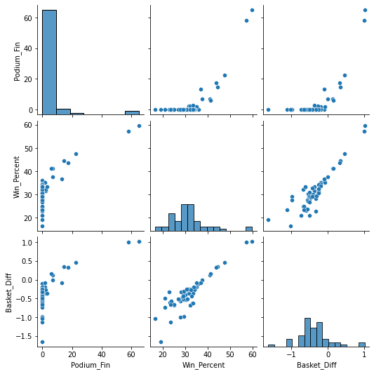

```python
sns.pairplot(basketball_data[['Podium_Fin', 'Win_Percent', 'Basket_Diff']]);
```

In a strip plot, the scatterplot points will usually overlap. This makes it difficult to see the full distribution of data. One easy solution is to adjust the positions (only along the categorical axis) using “jitter"

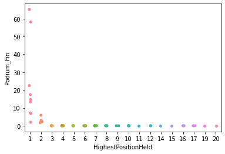

```python
sns.stripplot(basketball_data['HighestPositionHeld'], basketball_data['Podium_Fin'], jitter=True);
```

A different approach would be to use the function swarmplot(), which positions each scatterplot point on the categorical axis and avoids overlapping points:

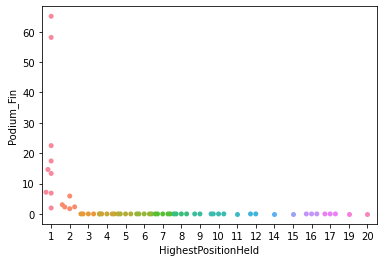

```python
sns.swarmplot(basketball_data['HighestPositionHeld'], basketball_data['Podium_Fin']);
```

## Boxplots

Another common graph is a boxplot(). This kind of plot shows the three quartile values of the distribution along with extreme values. The “whiskers” extend to points that lie within 1.5 IQRs of the lower and upper quartile, and then observations that fall outside this range are displayed independently.

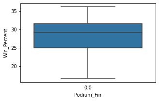

```python
plt.figure(figsize=(5,3))
df_temp=basketball_data[basketball_data['Podium_Fin']==0]
sns.boxplot(df_temp['Podium_Fin'], df_temp['Win_Percent']);
```

## Function to draw linear regression models

lmplot() is one of the most widely used function to quickly plot the Linear Relationship between 2 variables

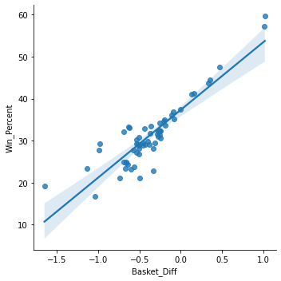

```python
sns.lmplot(y="Win_Percent", x="Basket_Diff", data=basketball_data);
```

```python
basketball_data.head()
```

|  | Team | Tournament | Score | PlayedGames | HighestPositionHeld | YearLaunch | Age | Basket_Diff | Win_Percent | Podium_Fin | SPG | Tour_Percent |
| --- | --- | --- | --- | --- | --- | --- | --- | --- | --- | --- | --- | --- |
| 0 | Team 1 | 86 | 4385 | 2762 | 1 | 1929 | 93 | 1.016293 | 59.630702 | 65.116279 | 1.587618 | 92.473118 |
| 1 | Team 2 | 86 | 4262 | 2762 | 1 | 1929 | 93 | 1.008689 | 57.241130 | 58.139535 | 1.543085 | 92.473118 |
| 2 | Team 3 | 80 | 3442 | 2614 | 1 | 1929 | 93 | 0.468630 | 47.475134 | 22.500000 | 1.316756 | 86.021505 |
| 3 | Team 4 | 82 | 3386 | 2664 | 1 | 1931 | 91 | 0.348724 | 44.557057 | 14.634146 | 1.271021 | 90.109890 |
| 4 | Team 5 | 86 | 3368 | 2762 | 1 | 1929 | 93 | 0.337075 | 43.772629 | 17.441860 | 1.219406 | 92.473118 |

```python
basketball_data['Win_Percent'].max()
```

```
59.630702389572775
```

```python
# Team which has highest Winratio
basketball_data.loc[(basketball_data['Win_Percent']) == (basketball_data['Win_Percent'].max())]
```

|  | Team | Tournament | Score | PlayedGames | HighestPositionHeld | YearLaunch | Age | Basket_Diff | Win_Percent | Podium_Fin | SPG | Tour_Percent |
| --- | --- | --- | --- | --- | --- | --- | --- | --- | --- | --- | --- | --- |
| 0 | Team 1 | 86 | 4385 | 2762 | 1 | 1929 | 93 | 1.016293 | 59.630702 | 65.116279 | 1.587618 | 92.473118 |

Thus, Team 1 has the highest winning ratio. Hence, Team 1 is best performing team

```python
# Team which has lowest Winratio
basketball_data.loc[(basketball_data['Win_Percent']) == (basketball_data['Win_Percent'].min())]
```

|  | Team | Tournament | Score | PlayedGames | HighestPositionHeld | YearLaunch | Age | Basket_Diff | Win_Percent | Podium_Fin | SPG | Tour_Percent |
| --- | --- | --- | --- | --- | --- | --- | --- | --- | --- | --- | --- | --- |
| 59 | Team 60 | 1 | 14 | 30 | 15 | 1955 | 67 | -1.033333 | 16.666667 | 0.0 | 0.466667 | 1.492537 |

Thus, Team 60 has the lowest winning ratio. Hence, Team 60 is poor performing team

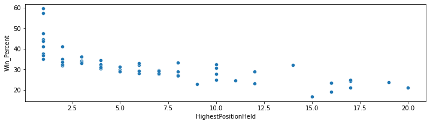

```python
#Plot of HighestPositionHeld against Win_Percent
plt.figure(figsize=(12,3))
df_temp=basketball_data[basketball_data['Win_Percent']>0]
sns.scatterplot(x=df_temp['HighestPositionHeld'],y=df_temp['Win_Percent']);
```

Teams with HighestPositionHeld < 10 tend to have Win_Pecent > 20%

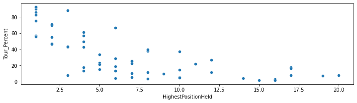

```python
plt.figure(figsize=(12,3))
df_temp=basketball_data[basketball_data['Win_Percent']>0]
sns.scatterplot(x=df_temp['HighestPositionHeld'],y=df_temp['Tour_Percent']);
```

The teams that have participated regularly in tournaments have higher chances of improving performance and achieving better positions on the table

```python
basketball_data.groupby(by='HighestPositionHeld').apply(display)
```

|  | Team | Tournament | Score | PlayedGames | HighestPositionHeld | YearLaunch | Age | Basket_Diff | Win_Percent | Podium_Fin | SPG | Tour_Percent |
| --- | --- | --- | --- | --- | --- | --- | --- | --- | --- | --- | --- | --- |
| 0 | Team 1 | 86 | 4385 | 2762 | 1 | 1929 | 93 | 1.016293 | 59.630702 | 65.116279 | 1.587618 | 92.473118 |
| 1 | Team 2 | 86 | 4262 | 2762 | 1 | 1929 | 93 | 1.008689 | 57.241130 | 58.139535 | 1.543085 | 92.473118 |
| 2 | Team 3 | 80 | 3442 | 2614 | 1 | 1929 | 93 | 0.468630 | 47.475134 | 22.500000 | 1.316756 | 86.021505 |
| 3 | Team 4 | 82 | 3386 | 2664 | 1 | 1931 | 91 | 0.348724 | 44.557057 | 14.634146 | 1.271021 | 90.109890 |
| 4 | Team 5 | 86 | 3368 | 2762 | 1 | 1929 | 93 | 0.337075 | 43.772629 | 17.441860 | 1.219406 | 92.473118 |
| 5 | Team 6 | 73 | 2819 | 2408 | 1 | 1934 | 88 | 0.127492 | 41.112957 | 6.849315 | 1.170681 | 82.954545 |
| 7 | Team 8 | 70 | 2573 | 2302 | 1 | 1929 | 93 | -0.000869 | 37.532580 | 7.142857 | 1.117724 | 75.268817 |
| 9 | Team 10 | 51 | 1884 | 1728 | 1 | 1932 | 90 | -0.192708 | 35.069444 | 1.960784 | 1.090278 | 56.666667 |
| 10 | Team 11 | 45 | 1814 | 1530 | 1 | 1941 | 81 | -0.088889 | 36.797386 | 13.333333 | 1.185621 | 55.555556 |

|  | Team | Tournament | Score | PlayedGames | HighestPositionHeld | YearLaunch | Age | Basket_Diff | Win_Percent | Podium_Fin | SPG | Tour_Percent |
| --- | --- | --- | --- | --- | --- | --- | --- | --- | --- | --- | --- | --- |
| 8 | Team 9 | 58 | 2109 | 1986 | 2 | 1939 | 83 | -0.082578 | 35.146022 | 1.724138 | 1.061934 | 69.879518 |
| 13 | Team 14 | 44 | 1416 | 1428 | 2 | 1929 | 93 | -0.367647 | 31.722689 | 2.272727 | 0.991597 | 47.311828 |
| 14 | Team 15 | 43 | 1389 | 1458 | 2 | 1944 | 78 | -0.273663 | 32.304527 | 2.325581 | 0.952675 | 55.128205 |
| 19 | Team 20 | 33 | 1020 | 1096 | 2 | 1951 | 71 | -0.364051 | 33.485401 | 3.030303 | 0.930657 | 46.478873 |
| 20 | Team 21 | 17 | 970 | 646 | 2 | 1998 | 24 | 0.159443 | 41.176471 | 5.882353 | 1.501548 | 70.833333 |

|  | Team | Tournament | Score | PlayedGames | HighestPositionHeld | YearLaunch | Age | Basket_Diff | Win_Percent | Podium_Fin | SPG | Tour_Percent |
| --- | --- | --- | --- | --- | --- | --- | --- | --- | --- | --- | --- | --- |
| 6 | Team 7 | 82 | 2792 | 2626 | 3 | 1929 | 93 | -0.106626 | 36.100533 | 0.0 | 1.063214 | 88.172043 |
| 17 | Team 18 | 38 | 1174 | 1192 | 3 | 1933 | 89 | -0.259228 | 34.228188 | 0.0 | 0.984899 | 42.696629 |
| 18 | Team 19 | 27 | 1148 | 988 | 3 | 1960 | 62 | -0.191296 | 33.704453 | 0.0 | 1.161943 | 43.548387 |
| 44 | Team 45 | 7 | 107 | 130 | 3 | 1929 | 93 | -0.623077 | 33.076923 | 0.0 | 0.823077 | 7.526882 |

|  | Team | Tournament | Score | PlayedGames | HighestPositionHeld | YearLaunch | Age | Basket_Diff | Win_Percent | Podium_Fin | SPG | Tour_Percent |
| --- | --- | --- | --- | --- | --- | --- | --- | --- | --- | --- | --- | --- |
| 11 | Team 12 | 51 | 1789 | 1698 | 4 | 1939 | 83 | -0.203769 | 34.511190 | 0.0 | 1.053592 | 61.445783 |
| 12 | Team 13 | 42 | 1471 | 1466 | 4 | 1948 | 74 | -0.281719 | 31.582538 | 0.0 | 1.003411 | 56.756757 |
| 15 | Team 16 | 37 | 1351 | 1318 | 4 | 1935 | 87 | -0.253414 | 32.321700 | 0.0 | 1.025038 | 42.528736 |
| 16 | Team 17 | 36 | 1314 | 1255 | 4 | 1949 | 73 | -0.272510 | 31.075697 | 0.0 | 1.047012 | 49.315068 |
| 31 | Team 32 | 14 | 353 | 426 | 4 | 1943 | 79 | -0.535211 | 30.281690 | 0.0 | 0.828638 | 17.721519 |
| 34 | Team 35 | 11 | 285 | 334 | 4 | 1941 | 81 | -0.505988 | 30.838323 | 0.0 | 0.853293 | 13.580247 |

|  | Team | Tournament | Score | PlayedGames | HighestPositionHeld | YearLaunch | Age | Basket_Diff | Win_Percent | Podium_Fin | SPG | Tour_Percent |
| --- | --- | --- | --- | --- | --- | --- | --- | --- | --- | --- | --- | --- |
| 23 | Team 24 | 21 | 606 | 678 | 5 | 1959 | 63 | -0.401180 | 29.941003 | 0.0 | 0.893805 | 33.333333 |
| 25 | Team 26 | 20 | 538 | 628 | 5 | 1935 | 87 | -0.531847 | 29.299363 | 0.0 | 0.856688 | 22.988506 |
| 26 | Team 27 | 13 | 510 | 494 | 5 | 1961 | 61 | -0.253036 | 31.376518 | 0.0 | 1.032389 | 21.311475 |
| 37 | Team 38 | 9 | 230 | 282 | 5 | 1962 | 60 | -0.514184 | 29.078014 | 0.0 | 0.815603 | 15.000000 |

|  | Team | Tournament | Score | PlayedGames | HighestPositionHeld | YearLaunch | Age | Basket_Diff | Win_Percent | Podium_Fin | SPG | Tour_Percent |
| --- | --- | --- | --- | --- | --- | --- | --- | --- | --- | --- | --- | --- |
| 21 | Team 22 | 23 | 667 | 742 | 6 | 1941 | 81 | -0.455526 | 29.380054 | 0.0 | 0.898922 | 28.395062 |
| 24 | Team 25 | 12 | 553 | 456 | 6 | 2004 | 18 | -0.247807 | 32.236842 | 0.0 | 1.212719 | 66.666667 |
| 28 | Team 29 | 12 | 421 | 380 | 6 | 1930 | 92 | -0.434211 | 32.894737 | 0.0 | 1.107895 | 13.043478 |
| 29 | Team 30 | 11 | 416 | 402 | 6 | 1963 | 59 | -0.502488 | 28.109453 | 0.0 | 1.034826 | 18.644068 |
| 51 | Team 52 | 4 | 56 | 72 | 6 | 1929 | 93 | -0.430556 | 29.166667 | 0.0 | 0.777778 | 4.301075 |

|  | Team | Tournament | Score | PlayedGames | HighestPositionHeld | YearLaunch | Age | Basket_Diff | Win_Percent | Podium_Fin | SPG | Tour_Percent |
| --- | --- | --- | --- | --- | --- | --- | --- | --- | --- | --- | --- | --- |
| 30 | Team 31 | 12 | 375 | 423 | 7 | 1974 | 48 | -0.375887 | 29.078014 | 0.0 | 0.886525 | 25.000000 |
| 33 | Team 34 | 9 | 293 | 346 | 7 | 1987 | 35 | -0.572254 | 27.745665 | 0.0 | 0.846821 | 25.714286 |
| 35 | Team 36 | 7 | 277 | 270 | 7 | 1991 | 31 | -0.333333 | 28.148148 | 0.0 | 1.025926 | 22.580645 |
| 41 | Team 42 | 6 | 150 | 180 | 7 | 1963 | 59 | -0.311111 | 29.444444 | 0.0 | 0.833333 | 10.169492 |
| 46 | Team 47 | 4 | 91 | 116 | 7 | 1947 | 75 | -0.982759 | 29.310345 | 0.0 | 0.784483 | 5.333333 |

|  | Team | Tournament | Score | PlayedGames | HighestPositionHeld | YearLaunch | Age | Basket_Diff | Win_Percent | Podium_Fin | SPG | Tour_Percent |
| --- | --- | --- | --- | --- | --- | --- | --- | --- | --- | --- | --- | --- |
| 22 | Team 23 | 17 | 662 | 652 | 8 | 1977 | 45 | -0.503067 | 28.987730 | 0.0 | 1.015337 | 37.777778 |
| 36 | Team 37 | 6 | 242 | 228 | 8 | 2007 | 15 | -0.535088 | 27.192982 | 0.0 | 1.061404 | 40.000000 |
| 39 | Team 40 | 5 | 188 | 186 | 8 | 1978 | 44 | -0.505376 | 26.881720 | 0.0 | 1.010753 | 11.363636 |
| 53 | Team 54 | 3 | 42 | 54 | 8 | 1929 | 93 | -0.629630 | 33.333333 | 0.0 | 0.777778 | 3.225806 |

|  | Team | Tournament | Score | PlayedGames | HighestPositionHeld | YearLaunch | Age | Basket_Diff | Win_Percent | Podium_Fin | SPG | Tour_Percent |
| --- | --- | --- | --- | --- | --- | --- | --- | --- | --- | --- | --- | --- |
| 45 | Team 46 | 3 | 96 | 114 | 9 | 1990 | 32 | -0.333333 | 22.807018 | 0.0 | 0.842105 | 9.375 |
| 60 | Team 61 | 1 | 0 | 0 | 9 | 2017 | 5 | NaN | NaN | 0.0 | NaN | 20.000 |

|  | Team | Tournament | Score | PlayedGames | HighestPositionHeld | YearLaunch | Age | Basket_Diff | Win_Percent | Podium_Fin | SPG | Tour_Percent |
| --- | --- | --- | --- | --- | --- | --- | --- | --- | --- | --- | --- | --- |
| 38 | Team 39 | 4 | 190 | 160 | 10 | 1994 | 28 | -0.262500 | 32.500000 | 0.0 | 1.187500 | 14.285714 |
| 43 | Team 44 | 3 | 132 | 114 | 10 | 2014 | 8 | -0.245614 | 30.701754 | 0.0 | 1.157895 | 37.500000 |
| 49 | Team 50 | 4 | 76 | 108 | 10 | 1945 | 77 | -0.990741 | 27.777778 | 0.0 | 0.703704 | 5.194805 |
| 52 | Team 53 | 2 | 52 | 68 | 10 | 1979 | 43 | -0.661765 | 25.000000 | 0.0 | 0.764706 | 4.651163 |

|  | Team | Tournament | Score | PlayedGames | HighestPositionHeld | YearLaunch | Age | Basket_Diff | Win_Percent | Podium_Fin | SPG | Tour_Percent |
| --- | --- | --- | --- | --- | --- | --- | --- | --- | --- | --- | --- | --- |
| 27 | Team 28 | 18 | 445 | 586 | 11 | 1940 | 82 | -0.656997 | 24.744027 | 0.0 | 0.759386 | 21.95122 |

|  | Team | Tournament | Score | PlayedGames | HighestPositionHeld | YearLaunch | Age | Basket_Diff | Win_Percent | Podium_Fin | SPG | Tour_Percent |
| --- | --- | --- | --- | --- | --- | --- | --- | --- | --- | --- | --- | --- |
| 32 | Team 33 | 12 | 343 | 448 | 12 | 1977 | 45 | -0.600446 | 23.214286 | 0.0 | 0.765625 | 26.666667 |
| 40 | Team 41 | 6 | 168 | 204 | 12 | 1971 | 51 | -0.460784 | 28.921569 | 0.0 | 0.823529 | 11.764706 |

|  | Team | Tournament | Score | PlayedGames | HighestPositionHeld | YearLaunch | Age | Basket_Diff | Win_Percent | Podium_Fin | SPG | Tour_Percent |
| --- | --- | --- | --- | --- | --- | --- | --- | --- | --- | --- | --- | --- |
| 50 | Team 51 | 3 | 71 | 90 | 14 | 1953 | 69 | -0.688889 | 32.222222 | 0.0 | 0.788889 | 4.347826 |

|  | Team | Tournament | Score | PlayedGames | HighestPositionHeld | YearLaunch | Age | Basket_Diff | Win_Percent | Podium_Fin | SPG | Tour_Percent |
| --- | --- | --- | --- | --- | --- | --- | --- | --- | --- | --- | --- | --- |
| 59 | Team 60 | 1 | 14 | 30 | 15 | 1955 | 67 | -1.033333 | 16.666667 | 0.0 | 0.466667 | 1.492537 |

|  | Team | Tournament | Score | PlayedGames | HighestPositionHeld | YearLaunch | Age | Basket_Diff | Win_Percent | Podium_Fin | SPG | Tour_Percent |
| --- | --- | --- | --- | --- | --- | --- | --- | --- | --- | --- | --- | --- |
| 54 | Team 55 | 2 | 40 | 68 | 16 | 1950 | 72 | -1.647059 | 19.117647 | 0.0 | 0.588235 | 2.777778 |
| 57 | Team 58 | 1 | 22 | 30 | 16 | 1956 | 66 | -0.666667 | 23.333333 | 0.0 | 0.733333 | 1.515152 |
| 58 | Team 59 | 1 | 19 | 30 | 16 | 1951 | 71 | -1.133333 | 23.333333 | 0.0 | 0.633333 | 1.408451 |

|  | Team | Tournament | Score | PlayedGames | HighestPositionHeld | YearLaunch | Age | Basket_Diff | Win_Percent | Podium_Fin | SPG | Tour_Percent |
| --- | --- | --- | --- | --- | --- | --- | --- | --- | --- | --- | --- | --- |
| 42 | Team 43 | 4 | 148 | 152 | 17 | 1999 | 23 | -0.644737 | 24.342105 | 0.0 | 0.973684 | 17.391304 |
| 47 | Team 48 | 2 | 83 | 80 | 17 | 1996 | 26 | -0.687500 | 25.000000 | 0.0 | 1.037500 | 7.692308 |
| 55 | Team 56 | 1 | 35 | 38 | 17 | 2016 | 6 | -0.500000 | 21.052632 | 0.0 | 0.921053 | 16.666667 |

|  | Team | Tournament | Score | PlayedGames | HighestPositionHeld | YearLaunch | Age | Basket_Diff | Win_Percent | Podium_Fin | SPG | Tour_Percent |
| --- | --- | --- | --- | --- | --- | --- | --- | --- | --- | --- | --- | --- |
| 48 | Team 49 | 2 | 81 | 80 | 19 | 1995 | 27 | -0.5625 | 23.75 | 0.0 | 1.0125 | 7.407407 |

|  | Team | Tournament | Score | PlayedGames | HighestPositionHeld | YearLaunch | Age | Basket_Diff | Win_Percent | Podium_Fin | SPG | Tour_Percent |
| --- | --- | --- | --- | --- | --- | --- | --- | --- | --- | --- | --- | --- |
| 56 | Team 57 | 1 | 34 | 38 | 20 | 2009 | 13 | -0.736842 | 21.052632 | 0.0 | 0.894737 | 7.692308 |

We see that historically its only teams aged > 80 that have finished first. Barring an exception, teams that have finished in Top 5 have all been >= 59 years old

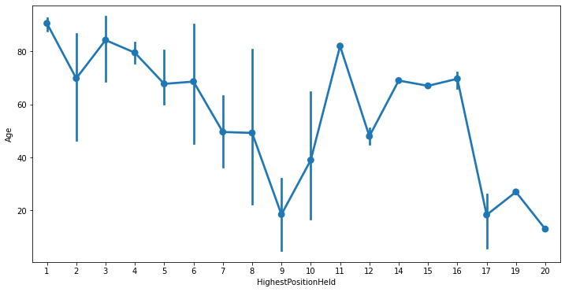

```python
plt.figure(figsize=(12,6))
sns.pointplot(x=basketball_data['HighestPositionHeld'],y=basketball_data['Age'],linewidth=0.25)
```

```python
#Print out the oldest teams
basketball_data[basketball_data['Age']==basketball_data['Age'].max()]
```

|  | Team | Tournament | Score | PlayedGames | HighestPositionHeld | YearLaunch | Age | Basket_Diff | Win_Percent | Podium_Fin | SPG | Tour_Percent |
| --- | --- | --- | --- | --- | --- | --- | --- | --- | --- | --- | --- | --- |
| 0 | Team 1 | 86 | 4385 | 2762 | 1 | 1929 | 93 | 1.016293 | 59.630702 | 65.116279 | 1.587618 | 92.473118 |
| 1 | Team 2 | 86 | 4262 | 2762 | 1 | 1929 | 93 | 1.008689 | 57.241130 | 58.139535 | 1.543085 | 92.473118 |
| 2 | Team 3 | 80 | 3442 | 2614 | 1 | 1929 | 93 | 0.468630 | 47.475134 | 22.500000 | 1.316756 | 86.021505 |
| 4 | Team 5 | 86 | 3368 | 2762 | 1 | 1929 | 93 | 0.337075 | 43.772629 | 17.441860 | 1.219406 | 92.473118 |
| 6 | Team 7 | 82 | 2792 | 2626 | 3 | 1929 | 93 | -0.106626 | 36.100533 | 0.000000 | 1.063214 | 88.172043 |
| 7 | Team 8 | 70 | 2573 | 2302 | 1 | 1929 | 93 | -0.000869 | 37.532580 | 7.142857 | 1.117724 | 75.268817 |
| 13 | Team 14 | 44 | 1416 | 1428 | 2 | 1929 | 93 | -0.367647 | 31.722689 | 2.272727 | 0.991597 | 47.311828 |
| 44 | Team 45 | 7 | 107 | 130 | 3 | 1929 | 93 | -0.623077 | 33.076923 | 0.000000 | 0.823077 | 7.526882 |
| 51 | Team 52 | 4 | 56 | 72 | 6 | 1929 | 93 | -0.430556 | 29.166667 | 0.000000 | 0.777778 | 4.301075 |
| 53 | Team 54 | 3 | 42 | 54 | 8 | 1929 | 93 | -0.629630 | 33.333333 | 0.000000 | 0.777778 | 3.225806 |

```python
#Identifying the teams that have played most games
basketball_data.sort_values('PlayedGames',ascending=False).head(3)
```

|  | Team | Tournament | Score | PlayedGames | HighestPositionHeld | YearLaunch | Age | Basket_Diff | Win_Percent | Podium_Fin | SPG | Tour_Percent |
| --- | --- | --- | --- | --- | --- | --- | --- | --- | --- | --- | --- | --- |
| 0 | Team 1 | 86 | 4385 | 2762 | 1 | 1929 | 93 | 1.016293 | 59.630702 | 65.116279 | 1.587618 | 92.473118 |
| 1 | Team 2 | 86 | 4262 | 2762 | 1 | 1929 | 93 | 1.008689 | 57.241130 | 58.139535 | 1.543085 | 92.473118 |
| 4 | Team 5 | 86 | 3368 | 2762 | 1 | 1929 | 93 | 0.337075 | 43.772629 | 17.441860 | 1.219406 | 92.473118 |

At an overall level, let us try to identify potential candidates for recommendation to Company X. We will capture the top 3 best performing teams across multiple parameters for performance and collate the list.

```python
#Defining a set to capture Potential Investment Candidates as derived through our analysis
candidates = set()
```

```python
#Identifying Top 3 teams basis SPG
basketball_data.sort_values('SPG',ascending=False).head(3)
```

|  | Team | Tournament | Score | PlayedGames | HighestPositionHeld | YearLaunch | Age | Basket_Diff | Win_Percent | Podium_Fin | SPG | Tour_Percent |
| --- | --- | --- | --- | --- | --- | --- | --- | --- | --- | --- | --- | --- |
| 0 | Team 1 | 86 | 4385 | 2762 | 1 | 1929 | 93 | 1.016293 | 59.630702 | 65.116279 | 1.587618 | 92.473118 |
| 1 | Team 2 | 86 | 4262 | 2762 | 1 | 1929 | 93 | 1.008689 | 57.241130 | 58.139535 | 1.543085 | 92.473118 |
| 20 | Team 21 | 17 | 970 | 646 | 2 | 1998 | 24 | 0.159443 | 41.176471 | 5.882353 | 1.501548 | 70.833333 |

```python
#Add these to candidates
candidates.update(basketball_data.sort_values('SPG',ascending=False).head(3)['Team'].unique())
candidates
```

```
{'Team 1', 'Team 2', 'Team 21'}
```

```python
#Similarly checking the lowest ranked teams by SPG
basketball_data.sort_values('SPG',ascending=False).tail(3)
```

|  | Team | Tournament | Score | PlayedGames | HighestPositionHeld | YearLaunch | Age | Basket_Diff | Win_Percent | Podium_Fin | SPG | Tour_Percent |
| --- | --- | --- | --- | --- | --- | --- | --- | --- | --- | --- | --- | --- |
| 54 | Team 55 | 2 | 40 | 68 | 16 | 1950 | 72 | -1.647059 | 19.117647 | 0.0 | 0.588235 | 2.777778 |
| 59 | Team 60 | 1 | 14 | 30 | 15 | 1955 | 67 | -1.033333 | 16.666667 | 0.0 | 0.466667 | 1.492537 |
| 60 | Team 61 | 1 | 0 | 0 | 9 | 2017 | 5 | NaN | NaN | 0.0 | NaN | 20.000000 |

```python
#Identifying Top 3 teams basis BasketDiff
basketball_data.sort_values('Basket_Diff',ascending=False).head(3)
```

|  | Team | Tournament | Score | PlayedGames | HighestPositionHeld | YearLaunch | Age | Basket_Diff | Win_Percent | Podium_Fin | SPG | Tour_Percent |
| --- | --- | --- | --- | --- | --- | --- | --- | --- | --- | --- | --- | --- |
| 0 | Team 1 | 86 | 4385 | 2762 | 1 | 1929 | 93 | 1.016293 | 59.630702 | 65.116279 | 1.587618 | 92.473118 |
| 1 | Team 2 | 86 | 4262 | 2762 | 1 | 1929 | 93 | 1.008689 | 57.241130 | 58.139535 | 1.543085 | 92.473118 |
| 2 | Team 3 | 80 | 3442 | 2614 | 1 | 1929 | 93 | 0.468630 | 47.475134 | 22.500000 | 1.316756 | 86.021505 |

This list is essentially the same as the Top 5 scorers, except Team 5. We will add that candidate to the list. Now, let us look at the Win_Percent and see which teams have won the most amount of matches they have played.

```python
candidates.update(basketball_data.sort_values('Basket_Diff',ascending=False).head(3)['Team'].unique())
basketball_data.sort_values('Basket_Diff',ascending=False).tail(3)
```

|  | Team | Tournament | Score | PlayedGames | HighestPositionHeld | YearLaunch | Age | Basket_Diff | Win_Percent | Podium_Fin | SPG | Tour_Percent |
| --- | --- | --- | --- | --- | --- | --- | --- | --- | --- | --- | --- | --- |
| 58 | Team 59 | 1 | 19 | 30 | 16 | 1951 | 71 | -1.133333 | 23.333333 | 0.0 | 0.633333 | 1.408451 |
| 54 | Team 55 | 2 | 40 | 68 | 16 | 1950 | 72 | -1.647059 | 19.117647 | 0.0 | 0.588235 | 2.777778 |
| 60 | Team 61 | 1 | 0 | 0 | 9 | 2017 | 5 | NaN | NaN | 0.0 | NaN | 20.000000 |

```python
#Identifying Top 3 teams basis Win_Percent
basketball_data.sort_values('Win_Percent',ascending=False).head(3)
```

|  | Team | Tournament | Score | PlayedGames | HighestPositionHeld | YearLaunch | Age | Basket_Diff | Win_Percent | Podium_Fin | SPG | Tour_Percent |
| --- | --- | --- | --- | --- | --- | --- | --- | --- | --- | --- | --- | --- |
| 0 | Team 1 | 86 | 4385 | 2762 | 1 | 1929 | 93 | 1.016293 | 59.630702 | 65.116279 | 1.587618 | 92.473118 |
| 1 | Team 2 | 86 | 4262 | 2762 | 1 | 1929 | 93 | 1.008689 | 57.241130 | 58.139535 | 1.543085 | 92.473118 |
| 2 | Team 3 | 80 | 3442 | 2614 | 1 | 1929 | 93 | 0.468630 | 47.475134 | 22.500000 | 1.316756 | 86.021505 |

No new candidates here

```python
#Similarly checking the lowest ranked teams by Win_Percent
basketball_data.sort_values('Win_Percent',ascending=False).tail(3)
```

|  | Team | Tournament | Score | PlayedGames | HighestPositionHeld | YearLaunch | Age | Basket_Diff | Win_Percent | Podium_Fin | SPG | Tour_Percent |
| --- | --- | --- | --- | --- | --- | --- | --- | --- | --- | --- | --- | --- |
| 54 | Team 55 | 2 | 40 | 68 | 16 | 1950 | 72 | -1.647059 | 19.117647 | 0.0 | 0.588235 | 2.777778 |
| 59 | Team 60 | 1 | 14 | 30 | 15 | 1955 | 67 | -1.033333 | 16.666667 | 0.0 | 0.466667 | 1.492537 |
| 60 | Team 61 | 1 | 0 | 0 | 9 | 2017 | 5 | NaN | NaN | 0.0 | NaN | 20.000000 |

```python
#Identifying Top 3 teams basis Podium_Fin
basketball_data.sort_values('Podium_Fin',ascending=False).head(3)
```

|  | Team | Tournament | Score | PlayedGames | HighestPositionHeld | YearLaunch | Age | Basket_Diff | Win_Percent | Podium_Fin | SPG | Tour_Percent |
| --- | --- | --- | --- | --- | --- | --- | --- | --- | --- | --- | --- | --- |
| 0 | Team 1 | 86 | 4385 | 2762 | 1 | 1929 | 93 | 1.016293 | 59.630702 | 65.116279 | 1.587618 | 92.473118 |
| 1 | Team 2 | 86 | 4262 | 2762 | 1 | 1929 | 93 | 1.008689 | 57.241130 | 58.139535 | 1.543085 | 92.473118 |
| 2 | Team 3 | 80 | 3442 | 2614 | 1 | 1929 | 93 | 0.468630 | 47.475134 | 22.500000 | 1.316756 | 86.021505 |

```python
#Similarly checking the lowest ranked teams by Podium_Fin
basketball_data.sort_values('Podium_Fin',ascending=False).tail(3)
```

|  | Team | Tournament | Score | PlayedGames | HighestPositionHeld | YearLaunch | Age | Basket_Diff | Win_Percent | Podium_Fin | SPG | Tour_Percent |
| --- | --- | --- | --- | --- | --- | --- | --- | --- | --- | --- | --- | --- |
| 33 | Team 34 | 9 | 293 | 346 | 7 | 1987 | 35 | -0.572254 | 27.745665 | 0.0 | 0.846821 | 25.714286 |
| 34 | Team 35 | 11 | 285 | 334 | 4 | 1941 | 81 | -0.505988 | 30.838323 | 0.0 | 0.853293 | 13.580247 |
| 60 | Team 61 | 1 | 0 | 0 | 9 | 2017 | 5 | NaN | NaN | 0.0 | NaN | 20.000000 |

```python
#Candidates now
candidates
```

```
{'Team 1', 'Team 2', 'Team 21', 'Team 3'}
```

Next, lets us look at the prevailling correlations between the data and see if any parameter correlates to Podium_Fin or TournamentChampion or Highest Position

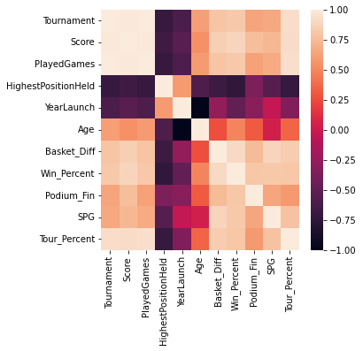

```python
plt.figure(figsize=(5,5))
sns.heatmap(basketball_data.corr())
```

```python
# Creating a temp dataframe for easier plotting
basketball_data_temp = basketball_data[['Team','Tournament','SPG','PlayedGames','Basket_Diff',
                                       'Age','Win_Percent','Podium_Fin','HighestPositionHeld','Tour_Percent']]
```

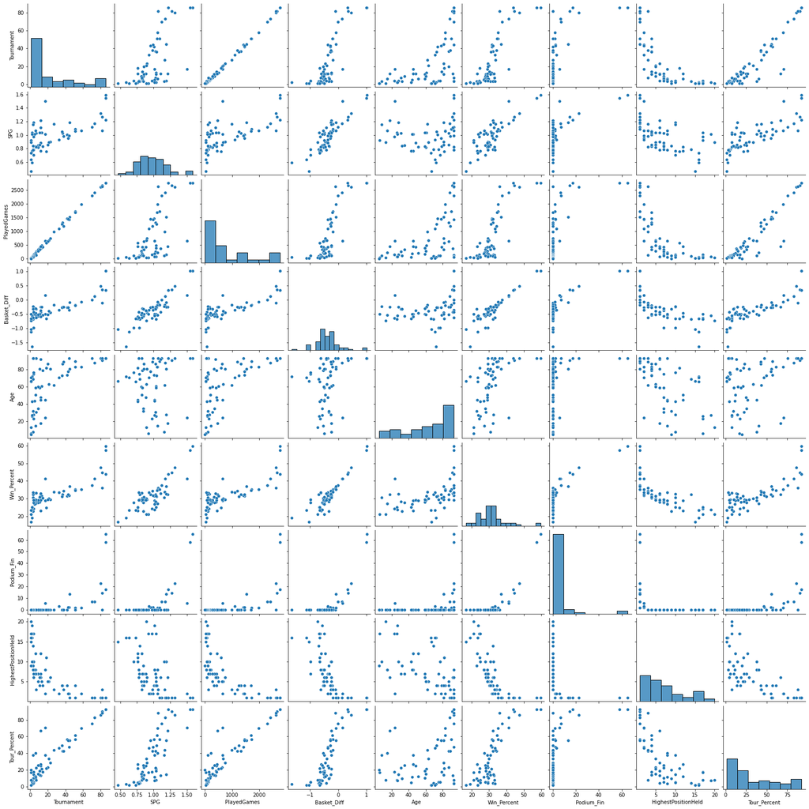

```python
sns.pairplot(basketball_data_temp)
```

The following are observed from the correlation heat-map and the pair-plots:

• HighestPositionHeld has an inverse relationship to Win Percent, Basket Diff, Podium Fin, SPG, and TourPercent.

• Podium Fin also has a correlation with Win Percent, Basket Diff, and SPG.

• Teams with a HighestPositionHeld score of 5 are over 40 years old (except one). They have also participated in the most events and have the best Win Percent and Podium Fin.

• It makes sense that as teams play more games (PlayedGames/Tournament), their chances of success (HighestPositionHeld/Podium Fin) rise as well. With more experience, the teams will improve and become more used to the tournament.

• For teams who have consistently placed in the top three or held high rankings, BasketDiff is greater than 0. It also has an inverse relationship with HighestPositionHeld and a positive correlation with Win Percent.

• Teams with high ranks or podium finishes at least once have win percentages that are high (>30%).

• SPG tends to be greater than 1 for teams with HighestPositionHeld less than 5

• Despite being established in the early years, many teams have not participated in as many competitions. Higher Tour Percent, Win Percent, BasketDiff, and Podium Fin are all evident. This suggests that success in tournaments depends on consistent involvement.

• There aren't many teams under 50 years old that have ever finished in the Top 5, but there are quite a few that have reached the Top 10.

Hence, for our recommendation process flow, we note that:

• Characteristics are distinct for older and newer teams. Newer teams take time to achieve high positions on the table. Hence, our approach should be different for older teams and emerging teams.

• Also, we see that chances of success increase with more games. We should track teams who play regularly in the tournament. Hence, we should establish a cut-off on the Tour_Percent as well.

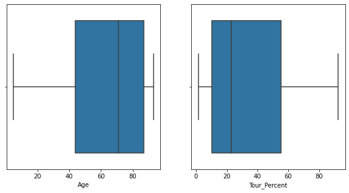

```python
#Box plot for Age and PlayedGames
fig, ax = plt.subplots(1,2)

fig.set_figheight(5)
fig.set_figwidth(10)

sns.boxplot(basketball_data['Age'],ax=ax[0])
sns.boxplot(basketball_data['Tour_Percent'],ax=ax[1])
```

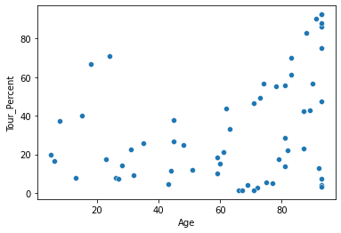

```python
sns.scatterplot(x=basketball_data['Age'],y=basketball_data['Tour_Percent'])
```

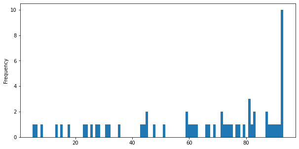

```python
plt.figure(figsize=(10,5))
basketball_data['Age'].plot.hist(bins=100)
```

For older teams, below are the cut-offs:

Age upper cut-off = 93.0 (max value)

Tour_Percent lower cut-off = 25% (median)

HighestPositionHeld cut-off = 6 (median)

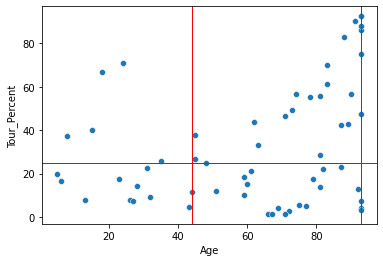

```python
sns.scatterplot(x=basketball_data['Age'],y=basketball_data['Tour_Percent'])
plt.axhline(25,linewidth=1,color = 'red')
plt.axvline(93,linewidth=1,color = 'red')
plt.axvline(44,linewidth=1,color = 'red')
```

```python
#Creating subset of dataset
basketball_data_oldest = basketball_data[(basketball_data['Age']<93) & (basketball_data['Age']>44) & (basketball_data['Tour_Percent']>25.0) & (basketball_data['HighestPositionHeld']<6)]
basketball_data_oldest
```

|  | Team | Tournament | Score | PlayedGames | HighestPositionHeld | YearLaunch | Age | Basket_Diff | Win_Percent | Podium_Fin | SPG | Tour_Percent |
| --- | --- | --- | --- | --- | --- | --- | --- | --- | --- | --- | --- | --- |
| 3 | Team 4 | 82 | 3386 | 2664 | 1 | 1931 | 91 | 0.348724 | 44.557057 | 14.634146 | 1.271021 | 90.109890 |
| 5 | Team 6 | 73 | 2819 | 2408 | 1 | 1934 | 88 | 0.127492 | 41.112957 | 6.849315 | 1.170681 | 82.954545 |
| 8 | Team 9 | 58 | 2109 | 1986 | 2 | 1939 | 83 | -0.082578 | 35.146022 | 1.724138 | 1.061934 | 69.879518 |
| 9 | Team 10 | 51 | 1884 | 1728 | 1 | 1932 | 90 | -0.192708 | 35.069444 | 1.960784 | 1.090278 | 56.666667 |
| 10 | Team 11 | 45 | 1814 | 1530 | 1 | 1941 | 81 | -0.088889 | 36.797386 | 13.333333 | 1.185621 | 55.555556 |
| 11 | Team 12 | 51 | 1789 | 1698 | 4 | 1939 | 83 | -0.203769 | 34.511190 | 0.000000 | 1.053592 | 61.445783 |
| 12 | Team 13 | 42 | 1471 | 1466 | 4 | 1948 | 74 | -0.281719 | 31.582538 | 0.000000 | 1.003411 | 56.756757 |
| 14 | Team 15 | 43 | 1389 | 1458 | 2 | 1944 | 78 | -0.273663 | 32.304527 | 2.325581 | 0.952675 | 55.128205 |
| 15 | Team 16 | 37 | 1351 | 1318 | 4 | 1935 | 87 | -0.253414 | 32.321700 | 0.000000 | 1.025038 | 42.528736 |
| 16 | Team 17 | 36 | 1314 | 1255 | 4 | 1949 | 73 | -0.272510 | 31.075697 | 0.000000 | 1.047012 | 49.315068 |
| 17 | Team 18 | 38 | 1174 | 1192 | 3 | 1933 | 89 | -0.259228 | 34.228188 | 0.000000 | 0.984899 | 42.696629 |
| 18 | Team 19 | 27 | 1148 | 988 | 3 | 1960 | 62 | -0.191296 | 33.704453 | 0.000000 | 1.161943 | 43.548387 |
| 19 | Team 20 | 33 | 1020 | 1096 | 2 | 1951 | 71 | -0.364051 | 33.485401 | 3.030303 | 0.930657 | 46.478873 |
| 23 | Team 24 | 21 | 606 | 678 | 5 | 1959 | 63 | -0.401180 | 29.941003 | 0.000000 | 0.893805 | 33.333333 |

For Emerging teams, below are the cut-offs:

Tour_Percent lower cut-off = 25% (median)

HighestPositionHeld cut-off = 10 (75%)

```python
#Creating subset of dataset
basketball_data_emer = basketball_data[(basketball_data['Age']<=44) & (basketball_data['Tour_Percent']>25) & (basketball_data['HighestPositionHeld']<=10)]
basketball_data_emer
```

|  | Team | Tournament | Score | PlayedGames | HighestPositionHeld | YearLaunch | Age | Basket_Diff | Win_Percent | Podium_Fin | SPG | Tour_Percent |
| --- | --- | --- | --- | --- | --- | --- | --- | --- | --- | --- | --- | --- |
| 20 | Team 21 | 17 | 970 | 646 | 2 | 1998 | 24 | 0.159443 | 41.176471 | 5.882353 | 1.501548 | 70.833333 |
| 24 | Team 25 | 12 | 553 | 456 | 6 | 2004 | 18 | -0.247807 | 32.236842 | 0.000000 | 1.212719 | 66.666667 |
| 33 | Team 34 | 9 | 293 | 346 | 7 | 1987 | 35 | -0.572254 | 27.745665 | 0.000000 | 0.846821 | 25.714286 |
| 36 | Team 37 | 6 | 242 | 228 | 8 | 2007 | 15 | -0.535088 | 27.192982 | 0.000000 | 1.061404 | 40.000000 |
| 43 | Team 44 | 3 | 132 | 114 | 10 | 2014 | 8 | -0.245614 | 30.701754 | 0.000000 | 1.157895 | 37.500000 |

```python
basketball_data_oldest=basketball_data_oldest.append(basketball_data[(basketball_data['Age']<=44) & (basketball_data['Tour_Percent']>25) & (basketball_data['HighestPositionHeld']<=10)]).sort_index()
basketball_data_oldest
```

|  | Team | Tournament | Score | PlayedGames | HighestPositionHeld | YearLaunch | Age | Basket_Diff | Win_Percent | Podium_Fin | SPG | Tour_Percent |
| --- | --- | --- | --- | --- | --- | --- | --- | --- | --- | --- | --- | --- |
| 3 | Team 4 | 82 | 3386 | 2664 | 1 | 1931 | 91 | 0.348724 | 44.557057 | 14.634146 | 1.271021 | 90.109890 |
| 5 | Team 6 | 73 | 2819 | 2408 | 1 | 1934 | 88 | 0.127492 | 41.112957 | 6.849315 | 1.170681 | 82.954545 |
| 8 | Team 9 | 58 | 2109 | 1986 | 2 | 1939 | 83 | -0.082578 | 35.146022 | 1.724138 | 1.061934 | 69.879518 |
| 9 | Team 10 | 51 | 1884 | 1728 | 1 | 1932 | 90 | -0.192708 | 35.069444 | 1.960784 | 1.090278 | 56.666667 |
| 10 | Team 11 | 45 | 1814 | 1530 | 1 | 1941 | 81 | -0.088889 | 36.797386 | 13.333333 | 1.185621 | 55.555556 |
| 11 | Team 12 | 51 | 1789 | 1698 | 4 | 1939 | 83 | -0.203769 | 34.511190 | 0.000000 | 1.053592 | 61.445783 |
| 12 | Team 13 | 42 | 1471 | 1466 | 4 | 1948 | 74 | -0.281719 | 31.582538 | 0.000000 | 1.003411 | 56.756757 |
| 14 | Team 15 | 43 | 1389 | 1458 | 2 | 1944 | 78 | -0.273663 | 32.304527 | 2.325581 | 0.952675 | 55.128205 |
| 15 | Team 16 | 37 | 1351 | 1318 | 4 | 1935 | 87 | -0.253414 | 32.321700 | 0.000000 | 1.025038 | 42.528736 |
| 16 | Team 17 | 36 | 1314 | 1255 | 4 | 1949 | 73 | -0.272510 | 31.075697 | 0.000000 | 1.047012 | 49.315068 |
| 17 | Team 18 | 38 | 1174 | 1192 | 3 | 1933 | 89 | -0.259228 | 34.228188 | 0.000000 | 0.984899 | 42.696629 |
| 18 | Team 19 | 27 | 1148 | 988 | 3 | 1960 | 62 | -0.191296 | 33.704453 | 0.000000 | 1.161943 | 43.548387 |
| 19 | Team 20 | 33 | 1020 | 1096 | 2 | 1951 | 71 | -0.364051 | 33.485401 | 3.030303 | 0.930657 | 46.478873 |
| 20 | Team 21 | 17 | 970 | 646 | 2 | 1998 | 24 | 0.159443 | 41.176471 | 5.882353 | 1.501548 | 70.833333 |
| 23 | Team 24 | 21 | 606 | 678 | 5 | 1959 | 63 | -0.401180 | 29.941003 | 0.000000 | 0.893805 | 33.333333 |
| 24 | Team 25 | 12 | 553 | 456 | 6 | 2004 | 18 | -0.247807 | 32.236842 | 0.000000 | 1.212719 | 66.666667 |
| 33 | Team 34 | 9 | 293 | 346 | 7 | 1987 | 35 | -0.572254 | 27.745665 | 0.000000 | 0.846821 | 25.714286 |
| 36 | Team 37 | 6 | 242 | 228 | 8 | 2007 | 15 | -0.535088 | 27.192982 | 0.000000 | 1.061404 | 40.000000 |
| 43 | Team 44 | 3 | 132 | 114 | 10 | 2014 | 8 | -0.245614 | 30.701754 | 0.000000 | 1.157895 | 37.500000 |

## Candidate Selection

Check if the candidate list pass the criteria

```python
basketball_data_oldest[basketball_data_oldest['Team'].isin(candidates)]
```

|  | Team | Tournament | Score | PlayedGames | HighestPositionHeld | YearLaunch | Age | Basket_Diff | Win_Percent | Podium_Fin | SPG | Tour_Percent |
| --- | --- | --- | --- | --- | --- | --- | --- | --- | --- | --- | --- | --- |
| 20 | Team 21 | 17 | 970 | 646 | 2 | 1998 | 24 | 0.159443 | 41.176471 | 5.882353 | 1.501548 | 70.833333 |

```python
candidates=set(basketball_data_oldest[basketball_data_oldest['Team'].isin(candidates)]['Team'].values)
```

```python
#Identifying top 3 teams by SPG
basketball_data_oldest.sort_values(by='SPG',ascending=False).head(3)
```

|  | Team | Tournament | Score | PlayedGames | HighestPositionHeld | YearLaunch | Age | Basket_Diff | Win_Percent | Podium_Fin | SPG | Tour_Percent |
| --- | --- | --- | --- | --- | --- | --- | --- | --- | --- | --- | --- | --- |
| 20 | Team 21 | 17 | 970 | 646 | 2 | 1998 | 24 | 0.159443 | 41.176471 | 5.882353 | 1.501548 | 70.833333 |
| 3 | Team 4 | 82 | 3386 | 2664 | 1 | 1931 | 91 | 0.348724 | 44.557057 | 14.634146 | 1.271021 | 90.109890 |
| 24 | Team 25 | 12 | 553 | 456 | 6 | 2004 | 18 | -0.247807 | 32.236842 | 0.000000 | 1.212719 | 66.666667 |

```python
candidates.update(basketball_data_oldest.sort_values(by='SPG',ascending=False).head(3)['Team'])
```

Identifying highest win_percent, Basket_Diff, Podium_Fin & updating candidates

```python
basketball_data_oldest.sort_values(by='Win_Percent',ascending=False).head(3)
```

|  | Team | Tournament | Score | PlayedGames | HighestPositionHeld | YearLaunch | Age | Basket_Diff | Win_Percent | Podium_Fin | SPG | Tour_Percent |
| --- | --- | --- | --- | --- | --- | --- | --- | --- | --- | --- | --- | --- |
| 3 | Team 4 | 82 | 3386 | 2664 | 1 | 1931 | 91 | 0.348724 | 44.557057 | 14.634146 | 1.271021 | 90.109890 |
| 20 | Team 21 | 17 | 970 | 646 | 2 | 1998 | 24 | 0.159443 | 41.176471 | 5.882353 | 1.501548 | 70.833333 |
| 5 | Team 6 | 73 | 2819 | 2408 | 1 | 1934 | 88 | 0.127492 | 41.112957 | 6.849315 | 1.170681 | 82.954545 |

```python
candidates.update(basketball_data_oldest.sort_values(by='Win_Percent',ascending=False).head(3)['Team'])
```

```python
basketball_data_oldest.sort_values(by='Basket_Diff',ascending=False).head(3)
```

|  | Team | Tournament | Score | PlayedGames | HighestPositionHeld | YearLaunch | Age | Basket_Diff | Win_Percent | Podium_Fin | SPG | Tour_Percent |
| --- | --- | --- | --- | --- | --- | --- | --- | --- | --- | --- | --- | --- |
| 3 | Team 4 | 82 | 3386 | 2664 | 1 | 1931 | 91 | 0.348724 | 44.557057 | 14.634146 | 1.271021 | 90.109890 |
| 20 | Team 21 | 17 | 970 | 646 | 2 | 1998 | 24 | 0.159443 | 41.176471 | 5.882353 | 1.501548 | 70.833333 |
| 5 | Team 6 | 73 | 2819 | 2408 | 1 | 1934 | 88 | 0.127492 | 41.112957 | 6.849315 | 1.170681 | 82.954545 |

```python
candidates.update(basketball_data_oldest.sort_values(by='Basket_Diff',ascending=False).head(3)['Team'])
```

```python
basketball_data_oldest.sort_values(by='Podium_Fin',ascending=False).head(3)
```

|  | Team | Tournament | Score | PlayedGames | HighestPositionHeld | YearLaunch | Age | Basket_Diff | Win_Percent | Podium_Fin | SPG | Tour_Percent |
| --- | --- | --- | --- | --- | --- | --- | --- | --- | --- | --- | --- | --- |
| 3 | Team 4 | 82 | 3386 | 2664 | 1 | 1931 | 91 | 0.348724 | 44.557057 | 14.634146 | 1.271021 | 90.109890 |
| 10 | Team 11 | 45 | 1814 | 1530 | 1 | 1941 | 81 | -0.088889 | 36.797386 | 13.333333 | 1.185621 | 55.555556 |
| 5 | Team 6 | 73 | 2819 | 2408 | 1 | 1934 | 88 | 0.127492 | 41.112957 | 6.849315 | 1.170681 | 82.954545 |

```python
candidates.update(basketball_data_oldest.sort_values(by='Podium_Fin',ascending=False).head(3)['Team'])
```

Identifying lowest win_percent, Basket_Diff, Podium_Fin

```python
basketball_data_oldest.sort_values(by='Win_Percent',ascending=False).tail(3)
```

|  | Team | Tournament | Score | PlayedGames | HighestPositionHeld | YearLaunch | Age | Basket_Diff | Win_Percent | Podium_Fin | SPG | Tour_Percent |
| --- | --- | --- | --- | --- | --- | --- | --- | --- | --- | --- | --- | --- |
| 23 | Team 24 | 21 | 606 | 678 | 5 | 1959 | 63 | -0.401180 | 29.941003 | 0.0 | 0.893805 | 33.333333 |
| 33 | Team 34 | 9 | 293 | 346 | 7 | 1987 | 35 | -0.572254 | 27.745665 | 0.0 | 0.846821 | 25.714286 |
| 36 | Team 37 | 6 | 242 | 228 | 8 | 2007 | 15 | -0.535088 | 27.192982 | 0.0 | 1.061404 | 40.000000 |

```python
basketball_data_oldest.sort_values(by='Basket_Diff',ascending=False).tail(3)
```

|  | Team | Tournament | Score | PlayedGames | HighestPositionHeld | YearLaunch | Age | Basket_Diff | Win_Percent | Podium_Fin | SPG | Tour_Percent |
| --- | --- | --- | --- | --- | --- | --- | --- | --- | --- | --- | --- | --- |
| 23 | Team 24 | 21 | 606 | 678 | 5 | 1959 | 63 | -0.401180 | 29.941003 | 0.0 | 0.893805 | 33.333333 |
| 36 | Team 37 | 6 | 242 | 228 | 8 | 2007 | 15 | -0.535088 | 27.192982 | 0.0 | 1.061404 | 40.000000 |
| 33 | Team 34 | 9 | 293 | 346 | 7 | 1987 | 35 | -0.572254 | 27.745665 | 0.0 | 0.846821 | 25.714286 |

```python
basketball_data_oldest.sort_values(by='Podium_Fin',ascending=False).tail(3)
```

|  | Team | Tournament | Score | PlayedGames | HighestPositionHeld | YearLaunch | Age | Basket_Diff | Win_Percent | Podium_Fin | SPG | Tour_Percent |
| --- | --- | --- | --- | --- | --- | --- | --- | --- | --- | --- | --- | --- |
| 12 | Team 13 | 42 | 1471 | 1466 | 4 | 1948 | 74 | -0.281719 | 31.582538 | 0.0 | 1.003411 | 56.756757 |
| 11 | Team 12 | 51 | 1789 | 1698 | 4 | 1939 | 83 | -0.203769 | 34.511190 | 0.0 | 1.053592 | 61.445783 |
| 43 | Team 44 | 3 | 132 | 114 | 10 | 2014 | 8 | -0.245614 | 30.701754 | 0.0 | 1.157895 | 37.500000 |

```python
basketball_data_oldest.sort_values(by='SPG',ascending=False).tail(3)
```

|  | Team | Tournament | Score | PlayedGames | HighestPositionHeld | YearLaunch | Age | Basket_Diff | Win_Percent | Podium_Fin | SPG | Tour_Percent |
| --- | --- | --- | --- | --- | --- | --- | --- | --- | --- | --- | --- | --- |
| 19 | Team 20 | 33 | 1020 | 1096 | 2 | 1951 | 71 | -0.364051 | 33.485401 | 3.030303 | 0.930657 | 46.478873 |
| 23 | Team 24 | 21 | 606 | 678 | 5 | 1959 | 63 | -0.401180 | 29.941003 | 0.000000 | 0.893805 | 33.333333 |
| 33 | Team 34 | 9 | 293 | 346 | 7 | 1987 | 35 | -0.572254 | 27.745665 | 0.000000 | 0.846821 | 25.714286 |

```python
#candidates at the moment
candidates
```

```
{'Team 11', 'Team 21', 'Team 25', 'Team 4', 'Team 6'}
```

```python
basketball_data_oldest_temp = basketball_data_oldest[basketball_data_oldest['Team'].isin(candidates)]
basketball_data_oldest_temp
```

|  | Team | Tournament | Score | PlayedGames | HighestPositionHeld | YearLaunch | Age | Basket_Diff | Win_Percent | Podium_Fin | SPG | Tour_Percent |
| --- | --- | --- | --- | --- | --- | --- | --- | --- | --- | --- | --- | --- |
| 3 | Team 4 | 82 | 3386 | 2664 | 1 | 1931 | 91 | 0.348724 | 44.557057 | 14.634146 | 1.271021 | 90.109890 |
| 5 | Team 6 | 73 | 2819 | 2408 | 1 | 1934 | 88 | 0.127492 | 41.112957 | 6.849315 | 1.170681 | 82.954545 |
| 10 | Team 11 | 45 | 1814 | 1530 | 1 | 1941 | 81 | -0.088889 | 36.797386 | 13.333333 | 1.185621 | 55.555556 |
| 20 | Team 21 | 17 | 970 | 646 | 2 | 1998 | 24 | 0.159443 | 41.176471 | 5.882353 | 1.501548 | 70.833333 |
| 24 | Team 25 | 12 | 553 | 456 | 6 | 2004 | 18 | -0.247807 | 32.236842 | 0.000000 | 1.212719 | 66.666667 |

Thus, we have shortlisted 5 candidates. These candidates satisfy our observations from pair plot. They all have Win_Percent > 30, SPG > 1.0. All have Podium_Fin > 0 except Team 25, which is an emerging team. Basket_Diff > 0 for all teams except Team 11 and Team 25.

```python
print('Final Candidates:', candidates)
```

```
Final Candidates: {'Team 11', 'Team 21', 'Team 25', 'Team 6', 'Team 4'}
```

**Recommendation to Company X:** Invest in any of the above teams. Teams 4, 6 and 11 are relatively older but best performers in multiple attributes. Teams 21 and 25 are emerging teams which have future potential.

### 3. Please include any improvements or suggestions to the association management on quality, quantity, variety, velocity, veracity etc. on the data points collected by the association to perform a better data analysis in future. At-least 1 suggestion for each point. [10 Marks]

Big data is a field of data science that explores how different tools, methodologies and techniques can be used to analyze extremely large and complex data sets, break them down and systematically derive insights and information from them. But to truly get the grasp of how complex big data is, the understanding of the 5 Vs of big data is necessary!

Depending on the business strategy — gathering, processing and visualization of data can help the company extract value and financial benefits from it.

Volume, velocity, variety, veracity and value are the five keys that enable big data to be a valuable business strategy.

## Quantity / Volume

• For any metric there are only 61 data points available, if we take a cut on any attribute, then there are very few datapoints left to do any significance analysis.

• The data could be made richer by adding individual match data form each of the tournaments.

Data is generated by countless sources and in different formats (structured, unstructured and semi-structured). Due to its rapid production in extremely large sets, companies that want to incorporate big data into their business strategies are beginning to substitute traditional tools and methods used for business intelligence and analytics with custom software and systems that enable them to effectively gather, store, process and present all of that data in real-time.

In this case, let's assume that the PlayedGames = WonGames + DrawnGames + LostGames

Having seperate column for PlayedGames is not required avoididng that can save Volume

Some other techiniques includes applying column level and table level compression will reduce the size of the table.

```python
basketball_data_vol = basketball_data.copy()

del basketball_data_vol['PlayedGames']
```

```python
basketball_data_vol.shape
```

```
(61, 11)
```

```python
basketball_data_vol.head()
```

|  | Team | Tournament | Score | HighestPositionHeld | YearLaunch | Age | Basket_Diff | Win_Percent | Podium_Fin | SPG | Tour_Percent |
| --- | --- | --- | --- | --- | --- | --- | --- | --- | --- | --- | --- |
| 0 | Team 1 | 86 | 4385 | 1 | 1929 | 93 | 1.016293 | 59.630702 | 65.116279 | 1.587618 | 92.473118 |
| 1 | Team 2 | 86 | 4262 | 1 | 1929 | 93 | 1.008689 | 57.241130 | 58.139535 | 1.543085 | 92.473118 |
| 2 | Team 3 | 80 | 3442 | 1 | 1929 | 93 | 0.468630 | 47.475134 | 22.500000 | 1.316756 | 86.021505 |
| 3 | Team 4 | 82 | 3386 | 1 | 1931 | 91 | 0.348724 | 44.557057 | 14.634146 | 1.271021 | 90.109890 |
| 4 | Team 5 | 86 | 3368 | 1 | 1929 | 93 | 0.337075 | 43.772629 | 17.441860 | 1.219406 | 92.473118 |

## Velocity

• The data could be updated for each match within a tournament to provide more data points for analysis.

• If we collect data frequently, we will also know updated information on the Operating Status of the teams, if any have stopped operations

The flow of data in today’s world is massive and continuous, and the speed at which data can be accessed directly impacts the decision-making process. The main goal is to gather, process and present data in as close to real-time as possible because even a smaller amount of real-time data can provide businesses with information and insights that will lead to better business results than large volumes of data that take a long time to be processed.

In this case, we have all information in a single table. This might take more time for a query to fetch the results. Instead, if we split the tables into different chunks having a common column as primary index(Team in this case), user can query the table that is required for them. This process will make the query execution time faster thereby will result in increased performance.

**Static Data** – This covers data which is unchanged over long periods, such as lookup data. This by its very nature does not have a high velocity, so is not going to be a driver when considering Big Data. **In our case - 'Team','Tournament','TeamLaunch' are Static Data.**

**Dynamic Data** – This represents a large portion of your current operational and customer data, which is regularly added to and updated, such as orders. Within this you will have two further sub divisions. **In our case - 'WonGames', 'DrawnGames', 'LostGames','BasketScored', 'BasketGiven', 'Score', 'TournamentChampion', 'Runner_up', 'HighestPositionHeld' are dynamic data.**

**Change** – Data which is updated on a regular basis, such as customer details that will have for example preference & contact, information change on an ongoing basis.

**Growth** – Data which grows regularly, such as outbound communication details that will be added to each time a customer is communicated with. Dynamic Data does have velocity and for some SMEs this is Big Data, if the number of transactions and communication activity is high. For most SMEs this is however, business as usual and can be managed using existing solutions. These first two data types will already exist within the business and be managed to differing levels through batch processes completed weekly or daily, with some systems extending to complete hourly, or even 15-minute updates of key data using drip feeds of changed data only, depending on business needs. The final type of data brings us to real-time or near real-time data, which is continually growing at rates of tens or hundreds of thousands of records per second.

**Continuous Data** – With the introduction of Machine Data and Social Data the continued supply of data at a phenomenal rate is a reality, meaning that the pool of data is always growing. This leads to the need to capture, store, analyse and drive insight faster, which is at the essence of Big Velocity in Big Data.